# TFM: Riesgo de crédito - Análisis, desarrollo y código

- **Variable loan_status en función de la variable loan_intent:**

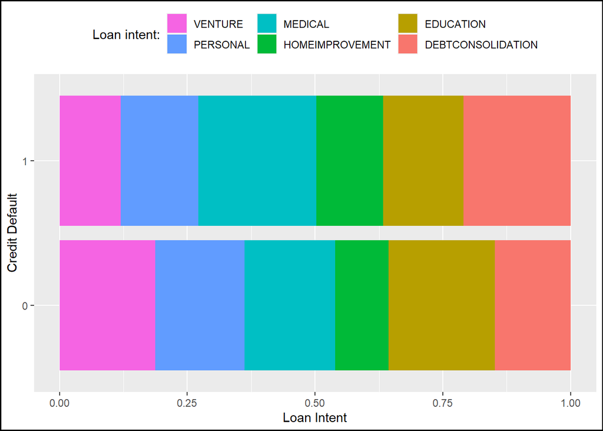

```r
ggplot(fcr_train, aes(x = factor(loan_status), fill = factor(loan_intent))) +
    geom_bar(position = "fill") + ylab("Loan Intent") + xlab("Credit Default") +
    labs(fill = "Loan intent:") + theme(legend.position = "top",
    plot.background = element_rect(colour = "black", size = 1)) +
    guides(fill = guide_legend(reverse = TRUE)) + coord_flip()
```

Con este gráfico se pasa a comparar a las personas que han incumplido con el pago del préstamo y las que no, con la finalidad del préstamo solicitado. Como hemos señalado antes, la variable de la finalidad del préstamo está bien distribuida, sin embargo, cuando el préstamo se dedica a la consolidación de deudas y con fines médicos, parece más probable que se produzca un impago de la deuda.

- **Variable loan_status en función de la variable loan_grade:**

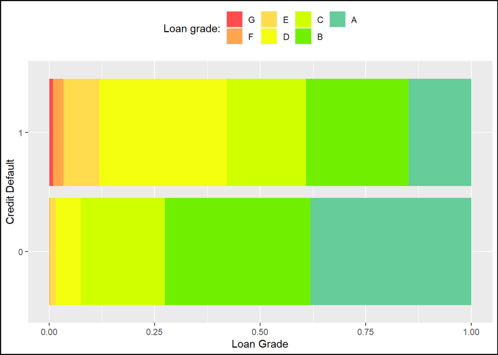

```r
ggplot(fcr_train, aes(x = factor(loan_status), fill = factor(loan_grade))) +
    geom_bar(position = "fill") + scale_fill_manual(values = c("#66cc99",
    "#70F000", "#D0FF00", "#F3FF0F", "#FFDB4D", "#FFA64D", "#FF4D4D")) +
    ylab("Loan Grade") + xlab("Credit Default") + labs(fill = "Loan grade:") +
    theme(legend.position = "top", plot.background = element_rect(colour = "black",
        size = 1)) + guides(fill = guide_legend(reverse = TRUE)) +
    coord_flip()
```

Utilizando de nuevo la paleta de colores para el grado de riesgo, es posible observar que esta variable tiene cierto poder predictivo de los impagos de los tomadores de crédito. Según los datos, cuando el grado de riesgo (scoring asignado a cada cliente en función del riesgo) es más bajo (calificación crediticia “A”), es menos probable que se produzca un impago. Lo contrario ocurre con los grados inferiores (“D”, “E”, “F” y “G”).

- **Variable loan_status en función de las variables loan_int_rate, person_income y loan_amnt:**

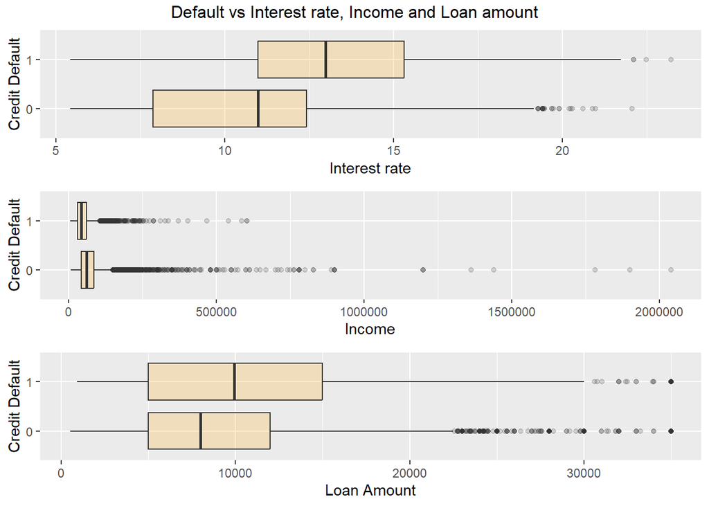

```r
g1 <- ggplot(fcr_train, aes(x = factor(loan_status), y = loan_int_rate)) +
    geom_boxplot(fill = "orange", alpha = 0.2) + ylab("Interest rate") +
    xlab("Credit Default") + coord_flip()

g2 <- ggplot(fcr_train, aes(x = factor(loan_status), y = person_income)) +
    geom_boxplot(fill = "orange", alpha = 0.2) + ylab("Income") +
    xlab("Credit Default") + coord_flip()

g3 <- ggplot(fcr_train, aes(x = factor(loan_status), y = loan_amnt)) +
    geom_boxplot(fill = "orange", alpha = 0.2) + ylab("Loan Amount") +
    xlab("Credit Default") + coord_flip()


grid.arrange(g1, g2, g3, ncol = 1, nrow = 3, top = "Default vs Interest rate, Income and Loan amount")
```

En este último gráfico se compara el riesgo de crédito con tres variables continuas: los tipos de interés, los ingresos anuales y el importe del préstamo. Este gráfico es interesante porque muestra claramente que unos tipos de interés más altos, unos ingresos más bajos y un crédito más elevado aumentan la posibilidad de impago.

# *APLICACIÓN DE LAS TÉCNICAS Y MODELOS DE MACHINE LEARNING*

En esta parte del trabajo, se trata de aplicar diferentes técnicas y algoritmos sobre los datos, de forma que se pueda llegar a la mejor predición y clasificación posible del riesgo de crédito. Para la comparación y selección del mejor algoritmo utilizaremos como métricas de evaluación: “Accuracy”, “Precision”, “Recall” y “F1 Score”, así como la “curva ROC”, y trataremos de establecer el mejor punto de corte posible que maximice la misma.

En este apartado se analizan diferentes algoritmos supervisados (aprendizaje supervisado, con datos etiquetados para su predicción o clasificación) sobre nuestro conjunto de datos sobre créditos bancarios.

# 7. GLM - Generalized Lineal Model

## 7.1. Variable de interés y análisis de relaciones entre variables

Primero se crean unos datos de train específicos para ser usados en el desarrollo del modelo GLM, y así mantener los originales sin modificar.

```r
fcr_train_glm <- fcr_train
fcr_train_glm
```

```
## # A tibble: 26,059 × 12
##    person_age person_i…¹ perso…² perso…³ loan_…⁴ loan_…⁵ loan_…⁶ loan_…⁷ loan_…⁸
##         <dbl>      <dbl> <fct>     <dbl> <fct>   <fct>     <dbl>   <dbl>   <dbl>
##  1         28      44000 RENT          2 MEDICAL C         10000   13.5        1
##  2         21      35000 OWN           5 VENTURE B          8000    9.91       0
##  3         25      96000 MORTGA…       6 HOMEIM… C         21000   14.6        0
##  4         22      67000 OWN           5 EDUCAT… D          7500   16.3        0
##  5         24      52800 RENT          8 PERSON… A          9000    7.49       0
##  6         27      50004 RENT         12 DEBTCO… B          3200   11.5        0
##  7         23      55488 RENT          4 MEDICAL D          5000   15.2        1
##  8         28      70000 RENT          2 DEBTCO… B          6000   10.4        0
##  9         22      55000 MORTGA…       6 PERSON… C         13000   13.8        0
## 10         26      43200 RENT          5 EDUCAT… C          3200   14.4        0
## # … with 26,049 more rows, 3 more variables: loan_percent_income <dbl>,
## #   cb_person_default_on_file <fct>, cb_person_cred_hist_length <dbl>, and
## #   abbreviated variable names ¹person_income, ²person_home_ownership,
## #   ³person_emp_length, ⁴loan_intent, ⁵loan_grade, ⁶loan_amnt, ⁷loan_int_rate,
## #   ⁸loan_status
```

```r
table(fcr_train_glm$loan_status)
```

```
##
##     0     1
## 20365  5694
```

```r
prop.table(table(fcr_train_glm$loan_status))
```

```
##
##         0         1
## 0.7814958 0.2185042
```

```r
str(fcr_train_glm)
```

```
## tibble [26,059 × 12] (S3: tbl_df/tbl/data.frame)
##  $ person_age                : num [1:26059] 28 21 25 22 24 27 23 28 22 26 ...
##  $ person_income             : num [1:26059] 44000 35000 96000 67000 52800 ...
##  $ person_home_ownership     : Factor w/ 4 levels "MORTGAGE","OTHER",..: 4 3 1 3 4 4 4 4 1 4 ...
##  $ person_emp_length         : num [1:26059] 2 5 6 5 8 12 4 2 6 5 ...
##  $ loan_intent               : Factor w/ 6 levels "DEBTCONSOLIDATION",..: 4 6 3 2 5 1 4 1 5 2 ...
##  $ loan_grade                : Factor w/ 7 levels "A","B","C","D",..: 3 2 3 4 1 2 4 2 3 3 ...
##  $ loan_amnt                 : num [1:26059] 10000 8000 21000 7500 9000 3200 5000 6000 13000 3200 ...
##  $ loan_int_rate             : num [1:26059] 13.48 9.91 14.65 16.29 7.49 ...
##  $ loan_status               : num [1:26059] 1 0 0 0 0 0 1 0 0 0 ...
##  $ loan_percent_income       : num [1:26059] 0.23 0.23 0.22 0.11 0.17 0.06 0.08 0.09 0.24 0.07 ...
##  $ cb_person_default_on_file : Factor w/ 2 levels "N","Y": 1 1 1 2 1 1 1 1 1 2 ...
##  $ cb_person_cred_hist_length: num [1:26059] 8 3 3 3 4 7 2 9 3 4 ...
```

Analizando la distinción entre créditos impagados y no impagados, se puede ver que la distibución entre ambos grupos está poco balanceada, con 20.365 no impagados (78.15%) y 5.694 (21.85%) impagados en los datos de train.

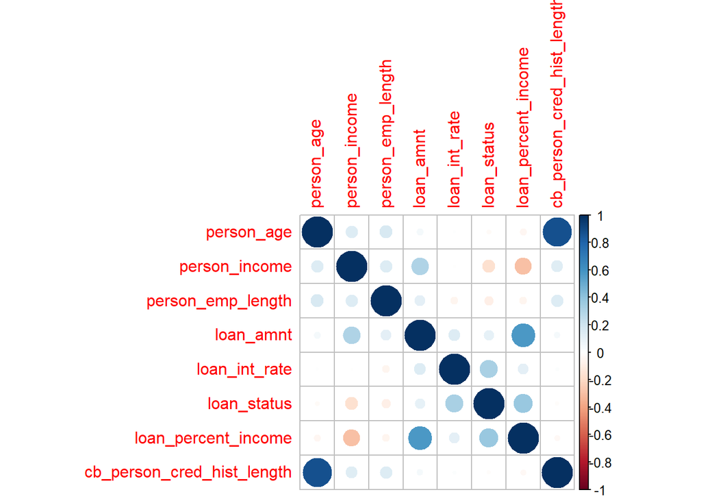

```r
corrplot(cor(fcr_train_glm %>%
    mutate(loan_status = as.numeric(loan_status)) %>%
    keep(is.numeric)))
```

```r
res <- cor(fcr_train_glm %>%
    mutate(loan_status = as.numeric(loan_status)) %>%
    keep(is.numeric))
round(res, 2)
```

```
##                            person_age person_income person_emp_length loan_amnt
## person_age                       1.00          0.15              0.17      0.05
## person_income                    0.15          1.00              0.15      0.31
## person_emp_length                0.17          0.15              1.00      0.11
## loan_amnt                        0.05          0.31              0.11      1.00
## loan_int_rate                    0.01         -0.01             -0.05      0.14
## loan_status                     -0.02         -0.17             -0.09      0.11
## loan_percent_income             -0.05         -0.29             -0.06      0.57
## cb_person_cred_hist_length       0.88          0.13              0.15      0.04
##                            loan_int_rate loan_status loan_percent_income
## person_age                          0.01       -0.02               -0.05
## person_income                      -0.01       -0.17               -0.29
## person_emp_length                  -0.05       -0.09               -0.06
## loan_amnt                           0.14        0.11                0.57
## loan_int_rate                       1.00        0.32                0.12
## loan_status                         0.32        1.00                0.38
## loan_percent_income                 0.12        0.38                1.00
## cb_person_cred_hist_length          0.02       -0.02               -0.04
##                            cb_person_cred_hist_length
## person_age                                       0.88
## person_income                                    0.13
## person_emp_length                                0.15
## loan_amnt                                        0.04
## loan_int_rate                                    0.02
## loan_status                                     -0.02
## loan_percent_income                             -0.04
## cb_person_cred_hist_length                       1.00
```

Se procede a analizar de forma bivariante las variables:

- **Variable loan_int_rate**

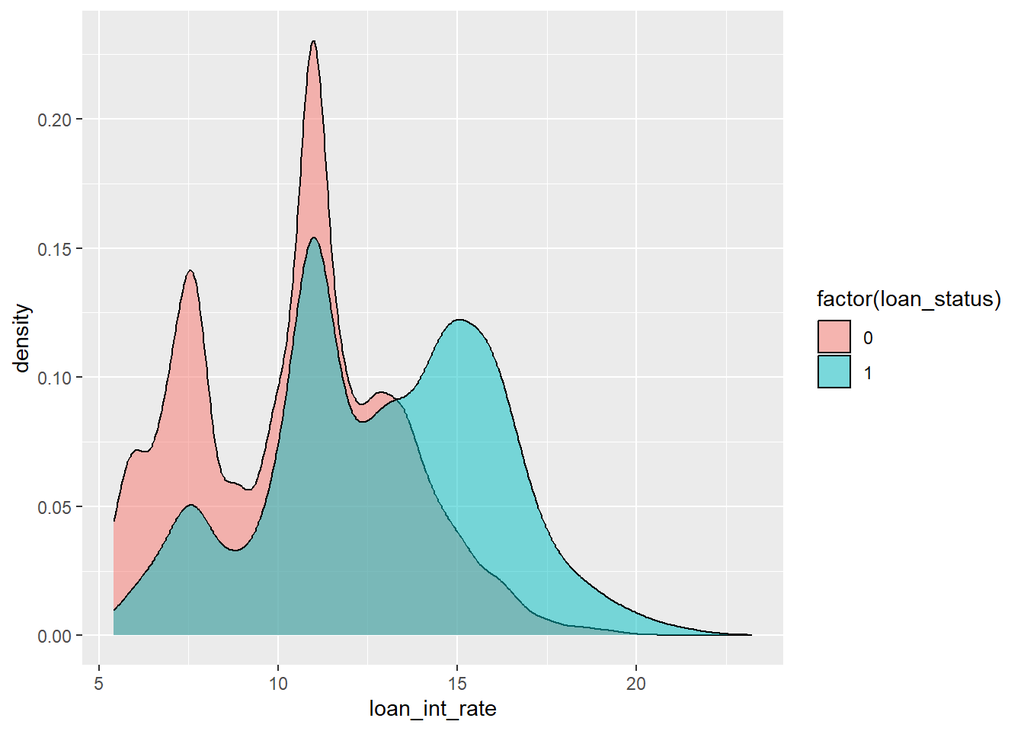

```r
fcr_train_glm %>%
    ggplot(aes(x = loan_int_rate, fill = factor(loan_status))) +
    geom_density(alpha = 0.5)
```

- **Variable loan_percent_income**

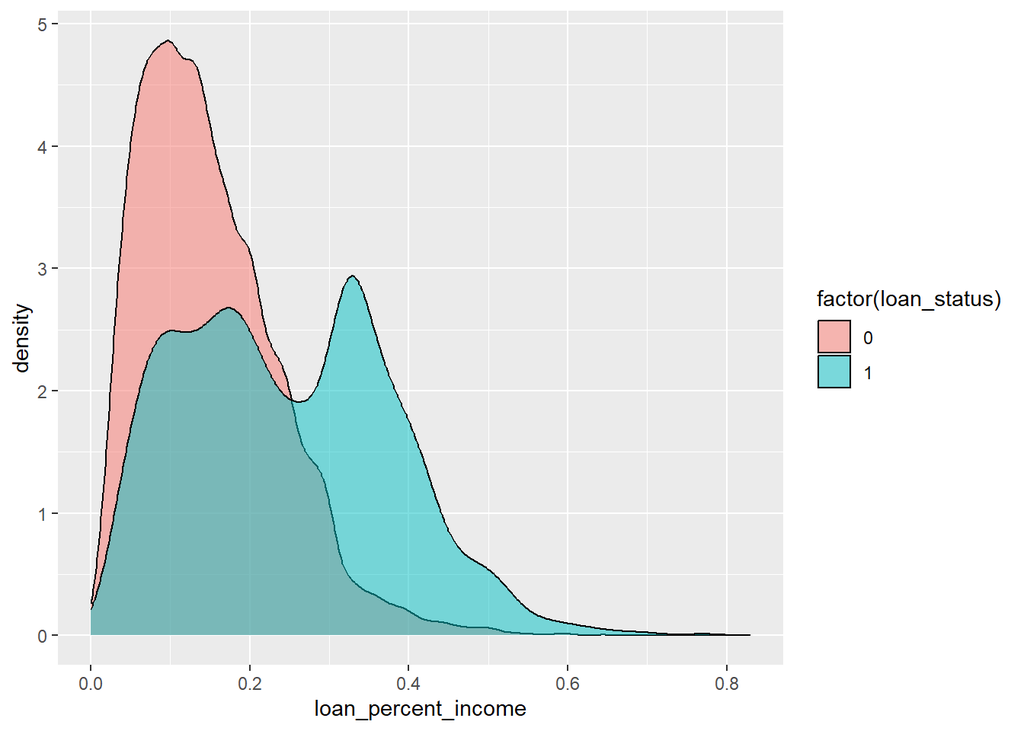

```r
fcr_train_glm %>%
    ggplot(aes(x = loan_percent_income, fill = factor(loan_status))) +
    geom_density(alpha = 0.5)
```

En términos generales vemos como los créditos analizados que están en la categoría de impagados, tienen en general un mayor valor de “loan_int_rate” y de “loan_percent_income”.

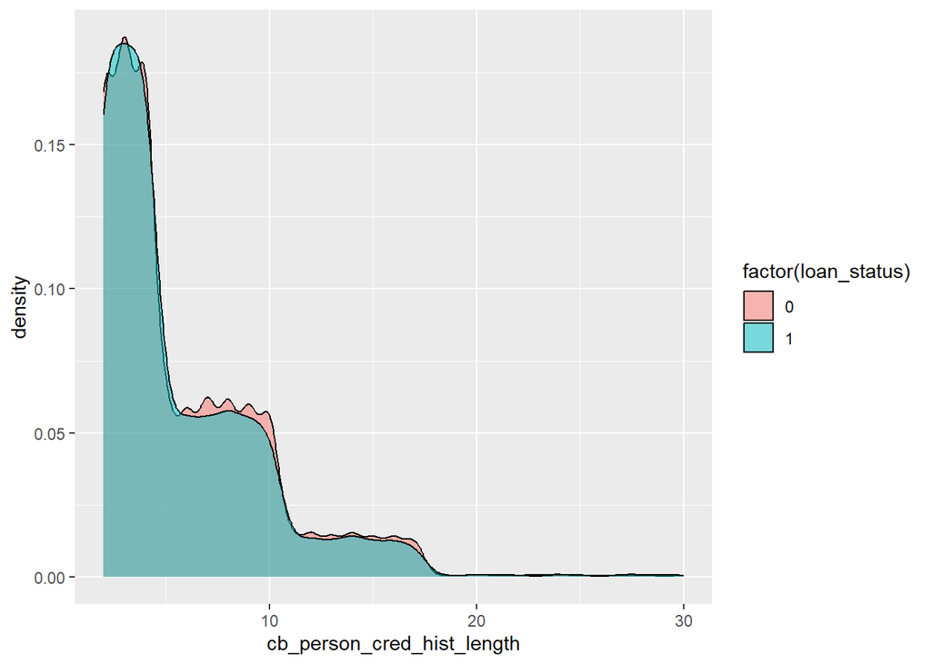

```r
fcr_train_glm %>%
    ggplot(aes(x = cb_person_cred_hist_length, fill = factor(loan_status))) +
    geom_density(alpha = 0.5)
```

- **Variable loan_amnt**

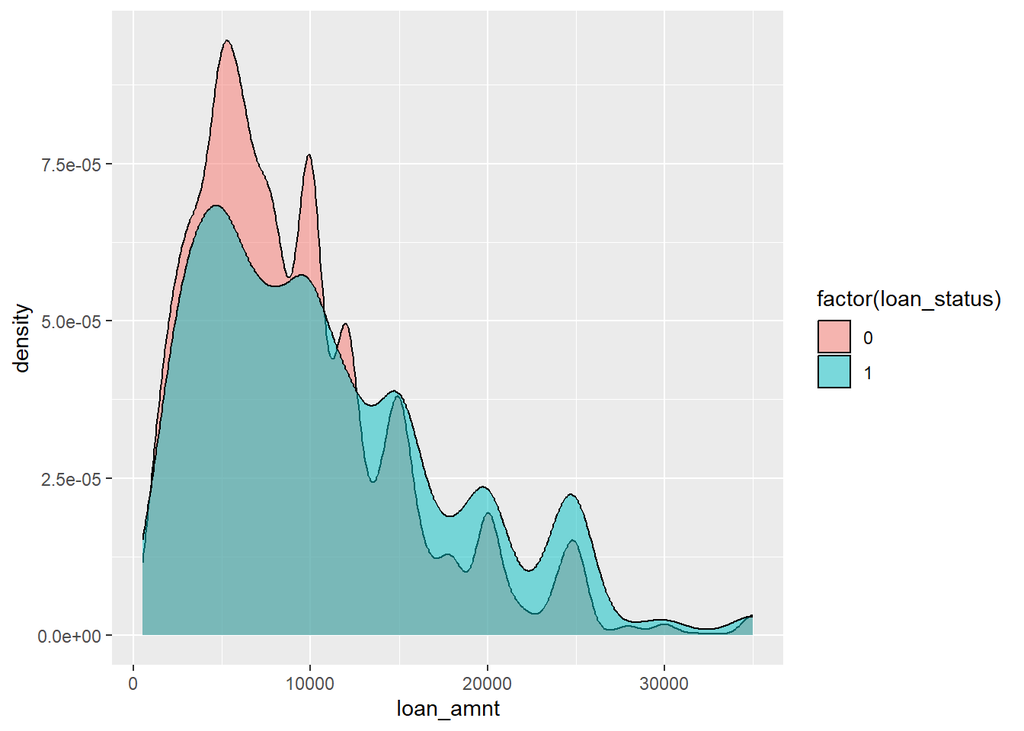

```r
fcr_train_glm %>%
    ggplot(aes(x = loan_amnt, fill = factor(loan_status))) +
    geom_density(alpha = 0.5)
```

- **Variable person_emp_length**

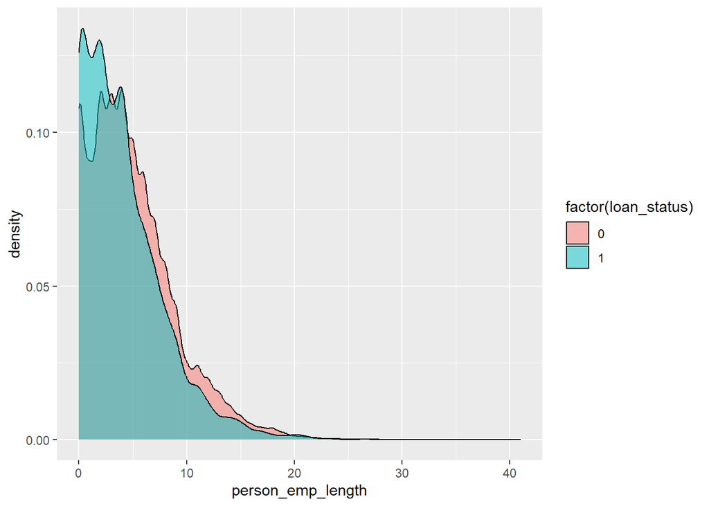

```r
fcr_train_glm %>%
    ggplot(aes(x = person_emp_length, fill = factor(loan_status))) +
    geom_density(alpha = 0.5)
```

- **Variable person_age**

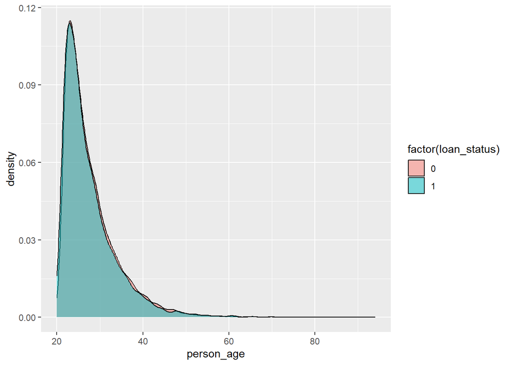

```r
fcr_train_glm %>%
    ggplot(aes(x = person_age, fill = factor(loan_status))) +
    geom_density(alpha = 0.5)
```

- **Variable person_income**

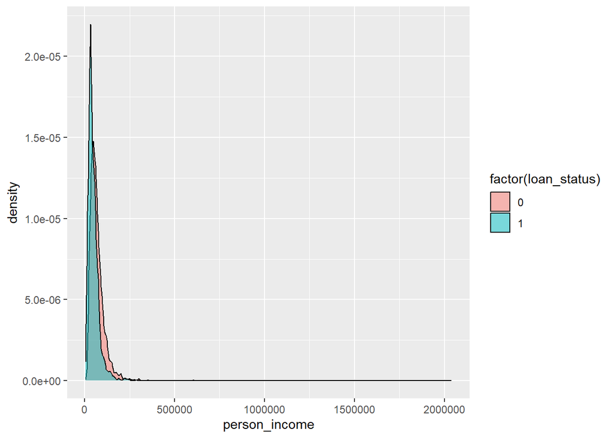

```r
fcr_train_glm %>%
    ggplot(aes(x = person_income, fill = factor(loan_status))) +
    geom_density(alpha = 0.5)
```

En los casos de las variables “cb_person_cred_hist_length”, “loan_amnt”, “person_emp_length”, “person_age” y “person_income”, cuesta más distinguir en el gráfico de densidad entre créditos impagados o no impagados, ya que no son características tan definitivas de un grupo u otro.

## 7.2. Creación del modelo de Regresión Logística

Se genera un modelo de regresión logística en base a las variables de nuestro dataset que sirva como predictor de la variable binaria creada.

```r
modelo_glm <- glm(loan_status ~ ., data = fcr_train_glm, family = binomial(link = "logit"))
modelo_glm
```

```
##
## Call:  glm(formula = loan_status ~ ., family = binomial(link = "logit"),
##     data = fcr_train_glm)
##
## Coefficients:
##                (Intercept)                  person_age
##                 -4.097e+00                  -4.897e-03
##              person_income  person_home_ownershipOTHER
##                  1.543e-06                   4.270e-01
##   person_home_ownershipOWN   person_home_ownershipRENT
##                 -1.750e+00                   8.360e-01
##          person_emp_length        loan_intentEDUCATION
##                 -1.351e-02                  -8.218e-01
## loan_intentHOMEIMPROVEMENT          loan_intentMEDICAL
##                  7.747e-02                  -1.494e-01
##        loan_intentPERSONAL          loan_intentVENTURE
##                 -5.980e-01                  -1.069e+00
##                loan_gradeB                 loan_gradeC
##                  2.463e-01                   4.670e-01
##                loan_gradeD                 loan_gradeE
##                  2.585e+00                   2.844e+00
##                loan_gradeF                 loan_gradeG
##                  3.396e+00                   6.754e+00
##                  loan_amnt               loan_int_rate
##                 -1.084e-04                   5.562e-02
##        loan_percent_income  cb_person_default_on_fileY
##                  1.344e+01                   2.107e-02
## cb_person_cred_hist_length
##                  2.282e-03
##
## Degrees of Freedom: 26058 Total (i.e. Null);  26036 Residual
## Null Deviance:       27360
## Residual Deviance: 17660     AIC: 17700
```

```r
summary(modelo_glm)
```

```
##
## Call:
## glm(formula = loan_status ~ ., family = binomial(link = "logit"),
##     data = fcr_train_glm)
##
## Deviance Residuals:
##     Min       1Q   Median       3Q      Max
## -3.2983  -0.5243  -0.3028  -0.1234   3.4420
##
## Coefficients:
##                              Estimate Std. Error z value Pr(>|z|)
## (Intercept)                -4.097e+00  1.938e-01 -21.143  < 2e-16 ***
## person_age                 -4.897e-03  6.501e-03  -0.753 0.451275
## person_income               1.543e-06  5.560e-07   2.775 0.005516 **
## person_home_ownershipOTHER  4.270e-01  3.168e-01   1.348 0.177707
## person_home_ownershipOWN   -1.750e+00  1.120e-01 -15.620  < 2e-16 ***
## person_home_ownershipRENT   8.360e-01  4.490e-02  18.621  < 2e-16 ***
## person_emp_length          -1.351e-02  5.387e-03  -2.509 0.012121 *
## loan_intentEDUCATION       -8.218e-01  6.364e-02 -12.913  < 2e-16 ***
## loan_intentHOMEIMPROVEMENT  7.747e-02  7.085e-02   1.093 0.274220
## loan_intentMEDICAL         -1.494e-01  5.993e-02  -2.493 0.012651 *
## loan_intentPERSONAL        -5.980e-01  6.508e-02  -9.189  < 2e-16 ***
## loan_intentVENTURE         -1.069e+00  6.926e-02 -15.436  < 2e-16 ***
## loan_gradeB                 2.463e-01  7.122e-02   3.458 0.000544 ***
## loan_gradeC                 4.670e-01  1.016e-01   4.598 4.26e-06 ***
## loan_gradeD                 2.585e+00  1.248e-01  20.715  < 2e-16 ***
## loan_gradeE                 2.844e+00  1.617e-01  17.590  < 2e-16 ***
## loan_gradeF                 3.396e+00  2.459e-01  13.811  < 2e-16 ***
## loan_gradeG                 6.754e+00  1.044e+00   6.470 9.80e-11 ***
## loan_amnt                  -1.084e-04  4.996e-06 -21.701  < 2e-16 ***
## loan_int_rate               5.562e-02  1.446e-02   3.845 0.000120 ***
## loan_percent_income         1.344e+01  2.895e-01  46.421  < 2e-16 ***
## cb_person_default_on_fileY  2.107e-02  5.581e-02   0.377 0.705835
## cb_person_cred_hist_length  2.282e-03  9.923e-03   0.230 0.818104
## ---
## Signif. codes:  0 '***' 0.001 '**' 0.01 '*' 0.05 '.' 0.1 ' ' 1
##
## (Dispersion parameter for binomial family taken to be 1)
##
##     Null deviance: 27362  on 26058  degrees of freedom
## Residual deviance: 17659  on 26036  degrees of freedom
## AIC: 17705
##
## Number of Fisher Scoring iterations: 6
```

Como observamos, nos quedamos solo con las variables significativas que relamente afectan a “loan_status”, y creamos un nuevo modelo exclusivamente con ellas. De esta forma simplificamos el modelo, nos quedamos con las varibales realmente importantes para el modelo predictor y creamos el mejor modelo de regresión logística posible para nuestro conjunto de datos. En principio las variables “cb_person_cred_hist_length”, “cb_person_default_on_file” y “person_age”, no parecen ser estadisticamente significativas.

Se podría también pensar en la exclusión del modelo, de la variable “loan_percent_income”, ya que de forma lógica y como se oberva en las correlaciones, es una variable que viene calculada, relaciona y explicada con las variables “person_income” y “loan_amnt”. Esto nos puede llegar a generar multicolinealidad y crear redundancia en los cálculos que hagamos para el modelo.

Finalmente se establece el siguiente modelo definitivo:

```r
modelo_glm2 <- glm(loan_status ~ person_income + person_emp_length +
    loan_amnt + loan_int_rate + person_home_ownership + loan_intent +
    loan_grade + loan_percent_income, data = fcr_train_glm, family = binomial)
modelo_glm2
```

```
##
## Call:  glm(formula = loan_status ~ person_income + person_emp_length +
##     loan_amnt + loan_int_rate + person_home_ownership + loan_intent +
##     loan_grade + loan_percent_income, family = binomial, data = fcr_train_glm)
##
## Coefficients:
##                (Intercept)               person_income
##                 -4.212e+00                   1.494e-06
##          person_emp_length                   loan_amnt
##                 -1.423e-02                  -1.084e-04
##              loan_int_rate  person_home_ownershipOTHER
##                  5.570e-02                   4.303e-01
##   person_home_ownershipOWN   person_home_ownershipRENT
##                 -1.750e+00                   8.350e-01
##       loan_intentEDUCATION  loan_intentHOMEIMPROVEMENT
##                 -8.187e-01                   7.264e-02
##         loan_intentMEDICAL         loan_intentPERSONAL
##                 -1.515e-01                  -5.987e-01
##         loan_intentVENTURE                 loan_gradeB
##                 -1.068e+00                   2.462e-01
##                loan_gradeC                 loan_gradeD
##                  4.767e-01                   2.595e+00
##                loan_gradeE                 loan_gradeF
##                  2.852e+00                   3.403e+00
##                loan_gradeG         loan_percent_income
##                  6.762e+00                   1.344e+01
##
## Degrees of Freedom: 26058 Total (i.e. Null);  26039 Residual
## Null Deviance:       27360
## Residual Deviance: 17660     AIC: 17700
```

```r
summary(modelo_glm2)
```

```
##
## Call:
## glm(formula = loan_status ~ person_income + person_emp_length +
##     loan_amnt + loan_int_rate + person_home_ownership + loan_intent +
##     loan_grade + loan_percent_income, family = binomial, data = fcr_train_glm)
##
## Deviance Residuals:
##     Min       1Q   Median       3Q      Max
## -3.2910  -0.5238  -0.3031  -0.1232   3.4357
##
## Coefficients:
##                              Estimate Std. Error z value Pr(>|z|)
## (Intercept)                -4.212e+00  1.426e-01 -29.527  < 2e-16 ***
## person_income               1.494e-06  5.540e-07   2.697 0.006994 **
## person_emp_length          -1.423e-02  5.343e-03  -2.663 0.007736 **
## loan_amnt                  -1.084e-04  4.996e-06 -21.708  < 2e-16 ***
## loan_int_rate               5.570e-02  1.446e-02   3.852 0.000117 ***
## person_home_ownershipOTHER  4.303e-01  3.162e-01   1.361 0.173558
## person_home_ownershipOWN   -1.750e+00  1.120e-01 -15.620  < 2e-16 ***
## person_home_ownershipRENT   8.350e-01  4.489e-02  18.602  < 2e-16 ***
## loan_intentEDUCATION       -8.187e-01  6.358e-02 -12.877  < 2e-16 ***
## loan_intentHOMEIMPROVEMENT  7.264e-02  7.071e-02   1.027 0.304260
## loan_intentMEDICAL         -1.515e-01  5.991e-02  -2.529 0.011446 *
## loan_intentPERSONAL        -5.987e-01  6.506e-02  -9.203  < 2e-16 ***
## loan_intentVENTURE         -1.068e+00  6.924e-02 -15.426  < 2e-16 ***
## loan_gradeB                 2.462e-01  7.121e-02   3.457 0.000547 ***
## loan_gradeC                 4.767e-01  9.753e-02   4.888 1.02e-06 ***
## loan_gradeD                 2.595e+00  1.213e-01  21.390  < 2e-16 ***
## loan_gradeE                 2.852e+00  1.594e-01  17.891  < 2e-16 ***
## loan_gradeF                 3.403e+00  2.448e-01  13.898  < 2e-16 ***
## loan_gradeG                 6.762e+00  1.044e+00   6.479 9.22e-11 ***
## loan_percent_income         1.344e+01  2.894e-01  46.437  < 2e-16 ***
## ---
## Signif. codes:  0 '***' 0.001 '**' 0.01 '*' 0.05 '.' 0.1 ' ' 1
##
## (Dispersion parameter for binomial family taken to be 1)
##
##     Null deviance: 27362  on 26058  degrees of freedom
## Residual deviance: 17660  on 26039  degrees of freedom
## AIC: 17700
##
## Number of Fisher Scoring iterations: 6
```

Los residuos de desviación tienen buen aspecto, aunque los valores no están completamente centrados en cero y no son simétricos. Las estimaciones son los parámetros de nuestro interés, mientras que la columna Pr(>|z|) muestra los valores p de dos colas que prueban la hipótesis nula de que el coeficiente es igual a cero. En otras palabras, muestra la importancia de los efectos de cada variable independiente. En nuestro modelo parece que la mayoría de las variables son estadísticamente significativas, sin embargo, para confirmar esta hipótesis procedemos a utilizar la prueba anova, observando la tabla de desviación.

```r
anova(modelo_glm2, test = "Chisq")
```

```
## Analysis of Deviance Table
##
## Model: binomial, link: logit
##
## Response: loan_status
##
## Terms added sequentially (first to last)
##
##
##                       Df Deviance Resid. Df Resid. Dev  Pr(>Chi)
## NULL                                  26058      27362
## person_income          1  1528.86     26057      25834 < 2.2e-16 ***
## person_emp_length      1    43.34     26056      25790 4.603e-11 ***
## loan_amnt              1  1637.16     26055      24153 < 2.2e-16 ***
## loan_int_rate          1  2409.06     26054      21744 < 2.2e-16 ***
## person_home_ownership  3   918.28     26051      20826 < 2.2e-16 ***
## loan_intent            5   393.83     26046      20432 < 2.2e-16 ***
## loan_grade             6  1294.56     26040      19137 < 2.2e-16 ***
## loan_percent_income    1  1477.25     26039      17660 < 2.2e-16 ***
## ---
## Signif. codes:  0 '***' 0.001 '**' 0.01 '*' 0.05 '.' 0.1 ' ' 1
```

La diferencia entre la desviación nula y la desviación residual muestra cómo se comporta nuestro modelo frente al modelo nulo, es decir, un modelo con sólo el intercepto. La prueba anova dice que añadir estas variables mejora el modelo de forma significativa, de hecho, los valores p bajos significan que las variables explican una gran parte de la variabilidad.

Ahora se puede analizar el ajuste e interpretar lo que nos dice el modelo. Como se ha analizado, el modelo sugiere que la mayoría de los p-valores muestran relevancia estadística en los resultados. Los únicos que no serían de la categoría HOMEIMPROVEMENT de la variable loan_intent y la categoría OTHER de la variable person_home_ownership, que no son significativos.

```r
cbind(Estimate = round(coef(modelo_glm2), 5), OR = round(exp(coef(modelo_glm2)),
    5))
```

```
##                            Estimate           OR
## (Intercept)                -4.21199      0.01482
## person_income               0.00000      1.00000
## person_emp_length          -0.01423      0.98587
## loan_amnt                  -0.00011      0.99989
## loan_int_rate               0.05570      1.05728
## person_home_ownershipOTHER  0.43033      1.53776
## person_home_ownershipOWN   -1.74974      0.17382
## person_home_ownershipRENT   0.83499      2.30478
## loan_intentEDUCATION       -0.81872      0.44100
## loan_intentHOMEIMPROVEMENT  0.07264      1.07535
## loan_intentMEDICAL         -0.15149      0.85943
## loan_intentPERSONAL        -0.59874      0.54950
## loan_intentVENTURE         -1.06814      0.34365
## loan_gradeB                 0.24616      1.27910
## loan_gradeC                 0.47674      1.61082
## loan_gradeD                 2.59458     13.39095
## loan_gradeE                 2.85180     17.31889
## loan_gradeF                 3.40255     30.04054
## loan_gradeG                 6.76201    864.37871
## loan_percent_income        13.43799 685561.75079
```

La columna Estimate calculada representa los coeficientes en forma de log-odds. Esto significa que cuando aumentamos la variable loan_int_rate en una unidad, podríamos esperar un cambio en las probabilidades logarítmicas de aproximadamente 0.05570. También podríamos utilizar esta información observando el signo de cada estimación, para entender si el efecto del predictor es positivo o negativo.

Según se puede observar en la tabla calculada, variables numéricas como person_emp_length o loan_amnt disminuyen las probabilidades de default, sin embargo, variables numéricas como loan_int_rate o loan_percent_income las incrementan.

Las variables categóricas deben interpretarse de forma un poco diferente. En este caso, la estimación representa el cambio en las probabilidades logarítmicas tomando como referencia una categoría base como, por ejemplo, en la regresión person_home_ownership-MORTAGE, loan_intent-DEBTCONSOLIDATION y loan_grade-A. En otras palabras, estar, por ejemplo, en la categoría loan_grade-B aumenta la log-odds de impago en 0.24616, con respecto a estar en loan_grade-A.

Según los resultados que obtenemos, cuando, por ejemplo, el parámetro del tipo de interés (variable loan_int_rate) aumenta una unidad (manteniendo constantes todos los demás predictores), las probabilidades de y = 1 (impago) son 1.05728 más altas o, dicho de otro modo, aumentan aproximadamente un 5.728%. La misma lógica se aplica a todas las demás variables, por lo que, por ejemplo, el aumento de la duración del empleo (variable person_emp_length) en una unidad conduce a una disminución de las probabilidades de impago de 0.98587.

Un elemento a tener en cuenta en el análisis es la variable loan_grade. Se puede observar que a medida que nos acercamos a grados inferiores, las probabilidades de impago aumentan enormemente. Como se dijo posteriormente, las variables categóricas deben interpretarse con respecto a la categoría base, así que en este caso comparando otros niveles con el grado A. Esta variable parece ser muy influyente y se podría decir que la graduación es adecuada y resulta útil para identificar posibles riesgos de impago para prestatarios y prestamistas.

Una interpretación de los coeficientes similar a la realizada sería:

```r
round(exp(cbind(Estimate = coef(modelo_glm2), confint(modelo_glm2))),
    2)
```

```
##                             Estimate     2.5 %     97.5 %
## (Intercept)                     0.01      0.01       0.02
## person_income                   1.00      1.00       1.00
## person_emp_length               0.99      0.98       1.00
## loan_amnt                       1.00      1.00       1.00
## loan_int_rate                   1.06      1.03       1.09
## person_home_ownershipOTHER      1.54      0.82       2.83
## person_home_ownershipOWN        0.17      0.14       0.22
## person_home_ownershipRENT       2.30      2.11       2.52
## loan_intentEDUCATION            0.44      0.39       0.50
## loan_intentHOMEIMPROVEMENT      1.08      0.94       1.23
## loan_intentMEDICAL              0.86      0.76       0.97
## loan_intentPERSONAL             0.55      0.48       0.62
## loan_intentVENTURE              0.34      0.30       0.39
## loan_gradeB                     1.28      1.11       1.47
## loan_gradeC                     1.61      1.33       1.95
## loan_gradeD                    13.39     10.57      17.00
## loan_gradeE                    17.32     12.68      23.69
## loan_gradeF                    30.04     18.68      48.82
## loan_gradeG                   864.38    170.97   15822.07
## loan_percent_income        685561.75 385886.22 1204041.39
```

Los intervalos de confianza no se basan en un test de Wald (como en regresión tradicional), sino en un perfilado (profiling) de la log-likelihood, que es más preciso.

Predicción de valores del modelo:

```r
head(predict(modelo_glm2))
```

```
##          1          2          3          4          5          6
## -0.2574225 -4.0274530 -2.1096365 -2.5847977 -2.2851013 -2.1276994
```

Probabilidad en escala de la salida:

```r
head(predict(modelo_glm2, type = "response"))
```

```
##          1          2          3          4          5          6
## 0.43599742 0.01750768 0.10816373 0.07012325 0.09236441 0.10643359
```

A la hora de desarrollar modelos de predicción, la métrica más importante es determinar la eficacia del modelo para predecir la variable objetivo en observaciones fuera de la muestra. Para ello, podemos comparar la variable objetivo predicha con los valores observados mediante la matriz de confusión.

Evaluación del rendimiento predictivo del modelo GLM presentado con las datos de train:

```r
fcr_train_glm$y_pred_probs <- predict(modelo_glm2, fcr_train_glm,
    type = "response")
fcr_train_glm$y_pred <- ifelse(fcr_train_glm$y_pred_probs > 0.5,
    1, 0)

# fcr_train_glm$y_pred_probs fcr_train_glm$y_pred
```

```r
cm_train <- confusionMatrix(as.factor(fcr_train_glm$y_pred),
    as.factor(fcr_train_glm$loan_status), positive = "1")
cm_train$table
```

```
##           Reference
## Prediction     0     1
##          0 19406  2503
##          1   959  3191
```

Más concretamente:

Se utilizan diferentes métricas de evaluación del modelo:

```r
# result
accuracy_modelo_glm2 <- cm_train$overall["Accuracy"] %>%
    round(4)
accuracy_modelo_glm2
```

```
## Accuracy
##   0.8671
```

```r
# result
recall_modelo_glm2 <- cm_train$byClass["Recall"] %>%
    round(4)
recall_modelo_glm2
```

```
## Recall
## 0.5604
```

```r
# result
precision_modelo_glm2 <- cm_train$byClass["Precision"] %>%
    round(4)
precision_modelo_glm2
```

```
## Precision
##    0.7689
```

```r
# result
F1Score_modelo_glm2 <- ((2 * precision_modelo_glm2 * recall_modelo_glm2)/(precision_modelo_glm2 +
    recall_modelo_glm2)) %>%
    round(4)
F1Score_modelo_glm2
```

```
## Precision
##    0.6483
```

Viendo el valor de las metricas obtenidas (con un punto de corte en 0.5), el valor de Accuracy (número de predicciones correctas/número total de predicciones) se situa en el 87%, el de Precision (positivos verdaderos/(positivos verdaderos + falsos positivos)) se situa en un 77%, el de Recall o Sensitividad (positivos verdaderos/(positivos verdaderos/falsos negativos)) en un 56% y el F1 Score (considerado como una media armónica que combina los valores de la precisión o precision y de la exhaustividad o recall) en un 65%.

Con estos datos se entiende que con el modelo desarrollado, en alrededor del 87% de los casos este será capaz de predecir si un crédito va a ser impagado o no.

## 7.3. GLM - Cross Validation, Hiperparámetros y Evaluación del modelo

Una vez desarrollado el modelo, se trata de aplicar Cross Validation sobre el modelo de GLM y realizar una selección de hiperparámetros (se busca tener un modelo robusto, generalizable y comparable con el resto para la posterior selección del mejor):

Primero se analizan cuales son las posibles variables que tienes el modelo para tratar de configurar. Cómo se puede ver, el modelo GLM no tiene la posibilidad de ajustar hiperparámetros.

```r
## https://machinelearningmastery.com/how-to-estimate-model-accuracy-in-r-using-the-caret-package/?msclkid=37e9f222aa8711ec9c857e7c4b89d202
## https://daviddalpiaz.github.io/r4sl/the-caret-package.html#classification

# Vemos hiperparámetros que se pueden configurar

modelLookup("glm")
```

```
##   model parameter     label forReg forClass probModel
## 1   glm parameter parameter   TRUE     TRUE      TRUE
```

Se crea el modelo con las variables seleccionadas como relevantes y haciendo Cross Validation on 5 particiones del dataset de train.

```r
caret.glm <- train(as.factor(loan_status) ~ person_income + person_emp_length +
    loan_amnt + loan_int_rate + person_home_ownership + loan_intent +
    loan_grade + loan_percent_income, method = "glm", family = "binomial",
    data = fcr_train_glm, trControl = trainControl(method = "cv",
        number = 5, search = "grid", returnResamp = "final"))
caret.glm
```

```
## Generalized Linear Model
##
## 26059 samples
##     8 predictor
##     2 classes: '0', '1'
##
## No pre-processing
## Resampling: Cross-Validated (5 fold)
## Summary of sample sizes: 20847, 20848, 20847, 20847, 20847
## Resampling results:
##
##   Accuracy   Kappa
##   0.8668023  0.5677015
```

```r
summary(caret.glm)
```

```
##
## Call:
## NULL
##
## Deviance Residuals:
##     Min       1Q   Median       3Q      Max
## -3.2910  -0.5238  -0.3031  -0.1232   3.4357
##
## Coefficients:
##                              Estimate Std. Error z value Pr(>|z|)
## (Intercept)                -4.212e+00  1.426e-01 -29.527  < 2e-16 ***
## person_income               1.494e-06  5.540e-07   2.697 0.006994 **
## person_emp_length          -1.423e-02  5.343e-03  -2.663 0.007736 **
## loan_amnt                  -1.084e-04  4.996e-06 -21.708  < 2e-16 ***
## loan_int_rate               5.570e-02  1.446e-02   3.852 0.000117 ***
## person_home_ownershipOTHER  4.303e-01  3.162e-01   1.361 0.173558
## person_home_ownershipOWN   -1.750e+00  1.120e-01 -15.620  < 2e-16 ***
## person_home_ownershipRENT   8.350e-01  4.489e-02  18.602  < 2e-16 ***
## loan_intentEDUCATION       -8.187e-01  6.358e-02 -12.877  < 2e-16 ***
## loan_intentHOMEIMPROVEMENT  7.264e-02  7.071e-02   1.027 0.304260
## loan_intentMEDICAL         -1.515e-01  5.991e-02  -2.529 0.011446 *
## loan_intentPERSONAL        -5.987e-01  6.506e-02  -9.203  < 2e-16 ***
## loan_intentVENTURE         -1.068e+00  6.924e-02 -15.426  < 2e-16 ***
## loan_gradeB                 2.462e-01  7.121e-02   3.457 0.000547 ***
## loan_gradeC                 4.767e-01  9.753e-02   4.888 1.02e-06 ***
## loan_gradeD                 2.595e+00  1.213e-01  21.390  < 2e-16 ***
## loan_gradeE                 2.852e+00  1.594e-01  17.891  < 2e-16 ***
## loan_gradeF                 3.403e+00  2.448e-01  13.898  < 2e-16 ***
## loan_gradeG                 6.762e+00  1.044e+00   6.479 9.22e-11 ***
## loan_percent_income         1.344e+01  2.894e-01  46.437  < 2e-16 ***
## ---
## Signif. codes:  0 '***' 0.001 '**' 0.01 '*' 0.05 '.' 0.1 ' ' 1
##
## (Dispersion parameter for binomial family taken to be 1)
##
##     Null deviance: 27362  on 26058  degrees of freedom
## Residual deviance: 17660  on 26039  degrees of freedom
## AIC: 17700
##
## Number of Fisher Scoring iterations: 6
```

Con estos datos se puede entender que con el modelo desarrollado, en alrededor del 86/87% de los casos este será capaz de predecir si un crédito va a ser impagado o no.

```r
confusionMatrix(caret.glm)
```

```
## Cross-Validated (5 fold) Confusion Matrix
##
## (entries are percentual average cell counts across resamples)
##
##           Reference
## Prediction    0    1
##          0 74.4  9.6
##          1  3.7 12.2
##
##  Accuracy (average) : 0.8668
```

```r
fcr_train_glm$y_pred_probs2 <- predict(caret.glm, fcr_train_glm,
    type = "prob")
fcr_train_glm$y_pred_probs2 <- ifelse(fcr_train_glm$y_pred_probs2$`1` >
    0.5, fcr_train_glm$y_pred_probs2$`1`, 1 - fcr_train_glm$y_pred_probs2$`0`)
fcr_train_glm$y_pred2 <- ifelse(fcr_train_glm$y_pred_probs2 >
    0.5, 1, 0)

# fcr_train_glm$y_pred_probs2 fcr_train_glm$y_pred2
```

Se reproduce la matriz de confusión y las métricas de evaluación sobre el modelo final de GLM obtenido:

```r
cm_train2 <- confusionMatrix(as.factor(fcr_train_glm$y_pred2),
    as.factor(fcr_train_glm$loan_status), positive = "1")
cm_train2$table
```

```
##           Reference
## Prediction     0     1
##          0 19406  2503
##          1   959  3191
```

```r
# result
accuracy_modelo_glm2_tune <- cm_train2$overall["Accuracy"] %>%
    round(4)
accuracy_modelo_glm2_tune
```

```
## Accuracy
##   0.8671
```

```r
# result
recall_modelo_glm2_tune <- cm_train2$byClass["Recall"] %>%
    round(4)
recall_modelo_glm2_tune
```

```
## Recall
## 0.5604
```

```r
# result
precision_modelo_glm2_tune <- cm_train2$byClass["Precision"] %>%
    round(4)
precision_modelo_glm2_tune
```

```
## Precision
##    0.7689
```

```r
# result
F1Score_modelo_glm2_tune <- (2 * (precision_modelo_glm2_tune *
    recall_modelo_glm2_tune)/(precision_modelo_glm2_tune + recall_modelo_glm2_tune)) %>%
    round(4)
F1Score_modelo_glm2_tune
```

```
## Precision
##    0.6483
```

Se reproduce la curva ROC sobre el modelo final de GLM obtenido:

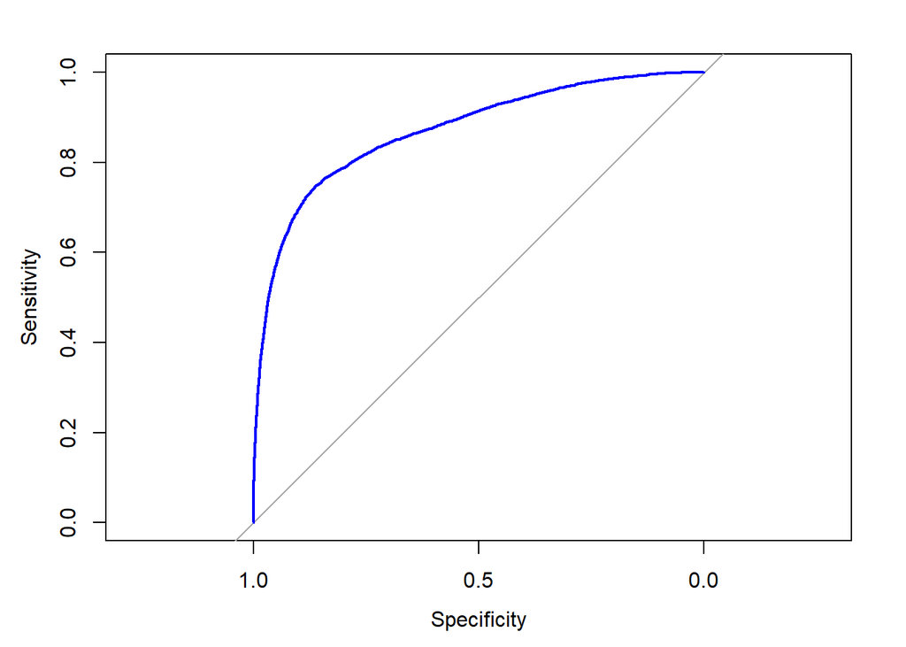

```r
roc_glm <- plot.roc(as.numeric(fcr_train_glm$loan_status), as.numeric(fcr_train_glm$y_pred_probs2),
    col = "blue")
```

```r
auc(roc_glm)
```

```
## Area under the curve: 0.8703
```

Se obtiene alrededor de un 87% de área bajo la curva.

El ROC es una curva que se genera trazando la tasa de verdaderos positivos (TPR) frente a la tasa de falsos positivos (FPR) en varios umbrales, mientras que el AUC es el área bajo la curva ROC. Dicho de otro modo, el ROC traza el porcentaje de verdaderos positivos predichos con exactitud por el modelo a medida que el umbral de probabilidad de predicción se reduce de 1 a 0. Muestra la compensación entre la tasa a la que se puede predecir correctamente algo con la tasa de predecir incorrectamente algo.

Por lo tanto, para un buen modelo, la curva debería aumentar de forma pronunciada, indicando que el TPR (eje Y) aumenta más rápido que el FPR (eje X) a medida que disminuye la puntuación de corte. Cuanto mayor sea el área bajo la curva ROC, mejor será la capacidad predictiva del modelo. Esa métrica oscila entre 0,50 y 1,00, y los valores superiores a 0,80 indican que el modelo hace un buen trabajo al discriminar entre las dos categorías que componen nuestra variable objetivo.

# 8. DECISION TREE

Primero se crean unos datos de train específicos para ser usados en el desarrollo del modelo de árbol de decisión, y así mantener los originales sin modificar.

```r
fcr_train_tree <- fcr_train
fcr_train_tree
```

```
## # A tibble: 26,059 × 12
##    person_age person_i…¹ perso…² perso…³ loan_…⁴ loan_…⁵ loan_…⁶ loan_…⁷ loan_…⁸
##         <dbl>      <dbl> <fct>     <dbl> <fct>   <fct>     <dbl>   <dbl>   <dbl>
##  1         28      44000 RENT          2 MEDICAL C         10000   13.5        1
##  2         21      35000 OWN           5 VENTURE B          8000    9.91       0
##  3         25      96000 MORTGA…       6 HOMEIM… C         21000   14.6        0
##  4         22      67000 OWN           5 EDUCAT… D          7500   16.3        0
##  5         24      52800 RENT          8 PERSON… A          9000    7.49       0
##  6         27      50004 RENT         12 DEBTCO… B          3200   11.5        0
##  7         23      55488 RENT          4 MEDICAL D          5000   15.2        1
##  8         28      70000 RENT          2 DEBTCO… B          6000   10.4        0
##  9         22      55000 MORTGA…       6 PERSON… C         13000   13.8        0
## 10         26      43200 RENT          5 EDUCAT… C          3200   14.4        0
## # … with 26,049 more rows, 3 more variables: loan_percent_income <dbl>,
## #   cb_person_default_on_file <fct>, cb_person_cred_hist_length <dbl>, and
## #   abbreviated variable names ¹person_income, ²person_home_ownership,
## #   ³person_emp_length, ⁴loan_intent, ⁵loan_grade, ⁶loan_amnt, ⁷loan_int_rate,
## #   ⁸loan_status
```

Se crea un modelo de árbol de decisión inicial básico y sin podar utilizando las 11 variables predictoras que tenemos a nuestra disposición y utilizando el método de “Gini” como medida de la impureza:

[figure not shown]

```r
# árbol de clasificación con las opciones por defecto (cp =
# 0.0001 y split = 'gini') con el comando:
tree = rpart(as.factor(loan_status) ~ ., data = fcr_train_tree,
    cp = 1e-04)
rpart.plot(tree, nn = TRUE, extra = 104, box.palette = "GnBu",
    branch.lty = 3, shadow.col = "gray")
```

```r
tree
```

```
## n= 26059
##
## node), split, n, loss, yval, (yprob)
##       * denotes terminal node
##
##       1) root 26059 5694 0 (0.781495836 0.218504164)
##         2) loan_percent_income< 0.305 22949 3525 0 (0.846398536 0.153601464)
##           4) loan_grade=A,B,C 19672 1666 0 (0.915311102 0.084688898)
##             8) person_income>=19996 19191 1340 0 (0.930175603 0.069824397)
##              16) person_income>=34850 16613  970 0 (0.941611991 0.058388009)
##                32) loan_grade=A,B 12942  583 0 (0.954952867 0.045047133)
##                  64) loan_intent=VENTURE 2275    0 0 (1.000000000 0.000000000) *
##                  65) loan_intent=DEBTCONSOLIDATION,EDUCATION,HOMEIMPROVEMENT,MEDICAL,PERSONAL 10667  583 0 (0.945345458 0.054654542)
##                   130) person_income>=59704 6364  255 0 (0.959930861 0.040069139)
##                     260) loan_int_rate< 8.435 2525   50 0 (0.980198020 0.019801980) *
##                     261) loan_int_rate>=8.435 3839  205 0 (0.946600677 0.053399323)
##                       522) person_income>=83602 1919   74 0 (0.961438249 0.038561751) *
##                       523) person_income< 83602 1920  131 0 (0.931770833 0.068229167)
##                        1046) person_income< 82725 1880  122 0 (0.935106383 0.064893617)
##                          2092) person_income< 60054 266    3 0 (0.988721805 0.011278195) *
##                          2093) person_income>=60054 1614  119 0 (0.926270136 0.073729864)
##                            4186) person_income>=64026 1347   85 0 (0.936896808 0.063103192)
##                              8372) person_income< 68843 362   10 0 (0.972375691 0.027624309) *
##                              8373) person_income>=68843 985   75 0 (0.923857868 0.076142132)
##                               16746) person_income>=69430 944   61 0 (0.935381356 0.064618644) *
##                               16747) person_income< 69430 41   14 0 (0.658536585 0.341463415)
##                                 33494) person_emp_length>=6.5 13    1 0 (0.923076923 0.076923077) *
##                                 33495) person_emp_length< 6.5 28   13 0 (0.535714286 0.464285714)
##                                   66990) cb_person_cred_hist_length< 3.5 11    3 0 (0.727272727 0.272727273) *
##                                   66991) cb_person_cred_hist_length>=3.5 17    7 1 (0.411764706 0.588235294) *
##                            4187) person_income< 64026 267   34 0 (0.872659176 0.127340824)
##                              8374) person_emp_length< 8.5 219   21 0 (0.904109589 0.095890411) *
##                              8375) person_emp_length>=8.5 48   13 0 (0.729166667 0.270833333)
##                               16750) loan_intent=DEBTCONSOLIDATION,EDUCATION,PERSONAL 27    4 0 (0.851851852 0.148148148) *
##                               16751) loan_intent=HOMEIMPROVEMENT,MEDICAL 21    9 0 (0.571428571 0.428571429)
##                                 33502) person_income>=62951.5 7    0 0 (1.000000000 0.000000000) *
##                                 33503) person_income< 62951.5 14    5 1 (0.357142857 0.642857143) *
##                        1047) person_income>=82725 40    9 0 (0.775000000 0.225000000)
##                          2094) person_age>=23.5 31    3 0 (0.903225806 0.096774194) *
##                          2095) person_age< 23.5 9    3 1 (0.333333333 0.666666667) *
```

[output cut: 345 more lines]

```
##                   201) person_home_ownership=MORTGAGE 100   29 0 (0.710000000 0.290000000)
##                     402) person_emp_length>=6.5 34    4 0 (0.882352941 0.117647059) *
##                     403) person_emp_length< 6.5 66   25 0 (0.621212121 0.378787879)
##                       806) loan_percent_income< 0.375 44   12 0 (0.727272727 0.272727273) *
##                       807) loan_percent_income>=0.375 22    9 1 (0.409090909 0.590909091)
##                        1614) loan_int_rate< 16.18 14    6 0 (0.571428571 0.428571429) *
##                        1615) loan_int_rate>=16.18 8    1 1 (0.125000000 0.875000000) *
##                 101) loan_grade=G 7    0 1 (0.000000000 1.000000000) *
##                51) loan_intent=DEBTCONSOLIDATION,MEDICAL 85    9 1 (0.105882353 0.894117647)
##                 102) person_home_ownership=OWN 21    9 1 (0.428571429 0.571428571)
##                   204) loan_grade=D 9    0 0 (1.000000000 0.000000000) *
##                   205) loan_grade=E,F,G 12    0 1 (0.000000000 1.000000000) *
##                 103) person_home_ownership=MORTGAGE 64    0 1 (0.000000000 1.000000000) *
##            13) person_income< 19900 68    0 1 (0.000000000 1.000000000) *
##           7) person_home_ownership=OTHER,RENT 1894    0 1 (0.000000000 1.000000000) *
```

Se analizan los resultados obtenidos de forma numérica:

```r
rpart.rules(tree, style = "tall")
```

```
## as.factor(loan_status) is 0.00 when
##     loan_percent_income < 0.305
##     loan_grade is A or B
##     person_income >= 34850
##     loan_intent is VENTURE
##
## as.factor(loan_status) is 0.00 when
##     loan_percent_income < 0.305
##     loan_grade is A or B
##     person_income is 62952 to 64026
##     loan_intent is HOMEIMPROVEMENT or MEDICAL
##     person_emp_length >= 9
##     loan_int_rate >= 8.4
##
## as.factor(loan_status) is 0.00 when
##     loan_percent_income < 0.045
##     loan_grade is C
##     person_income is 79996 to 107500
##     person_emp_length < 9
##     loan_int_rate < 13.3
##
## as.factor(loan_status) is 0.00 when
##     loan_percent_income < 0.305
##     loan_grade is C
##     person_income is 34850 to 79996
##     person_home_ownership is OTHER or OWN
##
## as.factor(loan_status) is 0.00 when
##     loan_percent_income < 0.305
##     loan_grade is A or B or C
##     person_income is 29002 to 34850
##     loan_intent is DEBTCONSOLIDATION or EDUCATION or PERSONAL
##     person_home_ownership is OWN
##     loan_int_rate >= 8.4
##     loan_amnt < 7013
##
## as.factor(loan_status) is 0.00 when
##     loan_percent_income is 0.065 to 0.305
##     loan_grade is A or B or C
##     person_income is 29002 to 32448
```

[output cut: 1602 more lines]

```
## as.factor(loan_status) is 1.00 when
##     loan_percent_income >= 0.305
##     loan_grade is D or E or F or G
##     person_income >= 19900
##     loan_intent is DEBTCONSOLIDATION or MEDICAL
##     person_home_ownership is MORTGAGE
##
## as.factor(loan_status) is 1.00 when
##     loan_percent_income >= 0.305
##     person_income < 19900
##     person_home_ownership is MORTGAGE or OWN
##
## as.factor(loan_status) is 1.00 when
##     loan_percent_income >= 0.305
##     person_home_ownership is OTHER or RENT
```

- **Modelo Decision Tree sin poda:**

```r
obs_tree1 <- as.factor(fcr_train_tree$loan_status)
head(predict(tree, newdata = fcr_train_tree))
```

```
##           0          1
## 1 0.9090909 0.09090909
## 2 1.0000000 0.00000000
## 3 0.9189189 0.08108108
## 4 0.9177215 0.08227848
## 5 0.9248609 0.07513915
## 6 0.8864469 0.11355311
```

```r
pred_tree1 <- predict(tree, newdata = fcr_train_tree, type = "class")
table(obs_tree1, pred_tree1)
```

```
##          pred_tree1
## obs_tree1     0     1
##         0 20174   191
##         1  1292  4402
```

```r
caret::confusionMatrix(pred_tree1, obs_tree1)
```

```
## Confusion Matrix and Statistics
##
##           Reference
## Prediction     0     1
##          0 20174  1292
##          1   191  4402
##
##                Accuracy : 0.9431
##                  95% CI : (0.9402, 0.9459)
##     No Information Rate : 0.7815
##     P-Value [Acc > NIR] : < 2.2e-16
##
##                   Kappa : 0.8209
##
##  Mcnemar's Test P-Value : < 2.2e-16
##
##             Sensitivity : 0.9906
##             Specificity : 0.7731
##          Pos Pred Value : 0.9398
##          Neg Pred Value : 0.9584
##              Prevalence : 0.7815
##          Detection Rate : 0.7742
##    Detection Prevalence : 0.8237
##       Balanced Accuracy : 0.8819
##
##        'Positive' Class : 0
##
```

Se obtiene un valor del 94.31% para la precisión del modelo, con el incoveniente de tener un modelo sin poda, demasiado complejo y que puede tender al sobreajuste.

Se realiza por ello la valoración para una posible poda del modelo que permita simplificarlo y hacerlo más explicativo sin perder capacidad predictora. Para ello vemos el CP o “Parámetro de complejidad” con el cual buscamos el árbol menos profundo que además minimice la tasa de error.

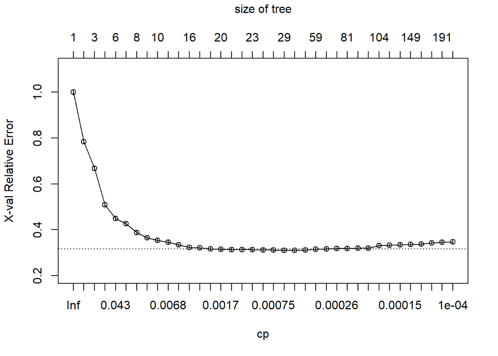

```r
plotcp(tree)
```

```r
# CP - PARÁMETRO DE COMPLEJIDAD: Buscamos el árbol menos
# profundo que además minimiza la tasa de error
```

```r
printcp(tree)
```

```
##
## Classification tree:
## rpart(formula = as.factor(loan_status) ~ ., data = fcr_train_tree,
##     cp = 1e-04)
##
## Variables actually used in tree construction:
##  [1] cb_person_cred_hist_length cb_person_default_on_file
##  [3] loan_amnt                  loan_grade
##  [5] loan_int_rate              loan_intent
##  [7] loan_percent_income        person_age
##  [9] person_emp_length          person_home_ownership
## [11] person_income
##
## Root node error: 5694/26059 = 0.2185
##
```

[output cut: 40 more lines]

Finalmente se decide proceder a realizar la poda y crear un modelo alternativo más simplificado y con menor sobreajuste:

```r
xerror <- tree$cptable[, "xerror"]
imin.xerror <- which.min(xerror)
upper.xerror <- xerror[imin.xerror] + tree$cptable[imin.xerror,
    "xstd"]
icp <- min(which(xerror <= upper.xerror))
cp <- tree$cptable[icp, "CP"]
cp
```

```
## [1] 0.001931858
```

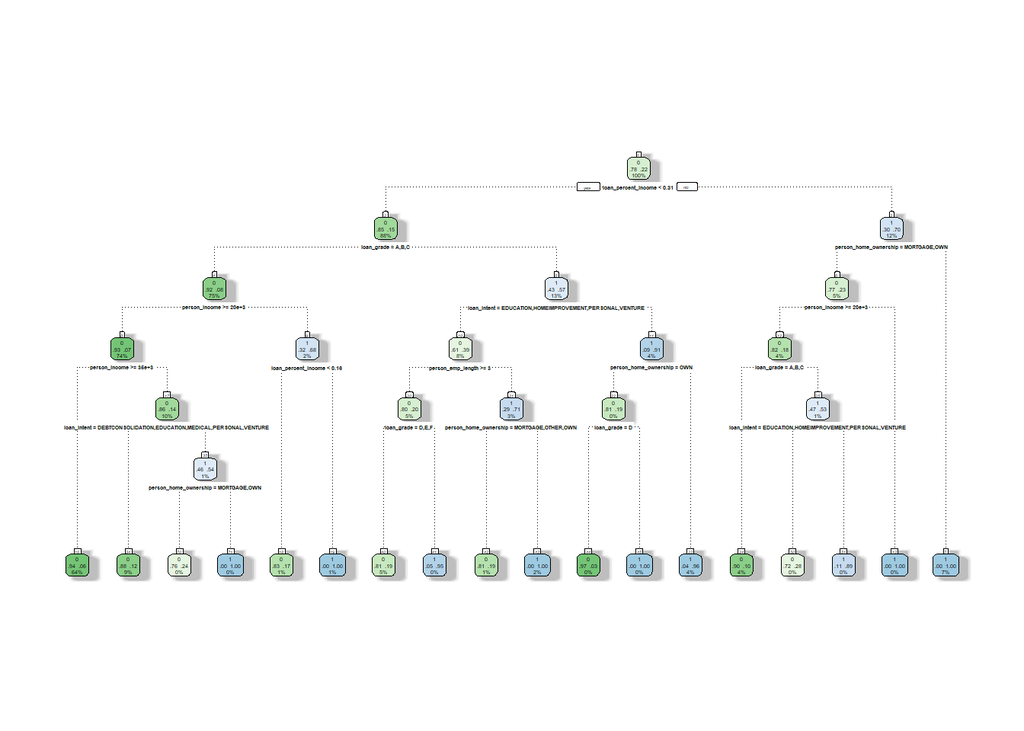

```r
tree_2 <- prune(tree, cp = cp)
# tree summary(tree) caret::varImp(tree) importance <-
# tree$variable.importance importance <-
# round(100*importance/sum(importance), 1)
# importance[importance >= 1]
rpart.plot(tree_2, nn = TRUE, extra = 104, box.palette = "GnBu",
    branch.lty = 3, shadow.col = "gray")  #, main='Classification tree winetaste'
```

- **Modelo Decision Tree con poda:**

```r
obs_tree2 <- as.factor(fcr_train_tree$loan_status)
head(predict(tree_2, newdata = fcr_train_tree))
```

```
##           0          1
## 1 0.9416120 0.05838801
## 2 0.9416120 0.05838801
## 3 0.9416120 0.05838801
## 4 0.8078078 0.19219219
## 5 0.9416120 0.05838801
## 6 0.9416120 0.05838801
```

```r
pred_tree2 <- predict(tree_2, newdata = fcr_train_tree, type = "class")
table(obs_tree2, pred_tree2)
```

```
##          pred_tree2
## obs_tree2     0     1
##         0 20309    56
##         1  1748  3946
```

```r
caret::confusionMatrix(pred_tree2, obs_tree2)
```

```
## Confusion Matrix and Statistics
##
##           Reference
## Prediction     0     1
##          0 20309  1748
##          1    56  3946
##
##                Accuracy : 0.9308
##                  95% CI : (0.9276, 0.9338)
##     No Information Rate : 0.7815
##     P-Value [Acc > NIR] : < 2.2e-16
##
##                   Kappa : 0.773
##
##  Mcnemar's Test P-Value : < 2.2e-16
##
##             Sensitivity : 0.9973
##             Specificity : 0.6930
##          Pos Pred Value : 0.9208
##          Neg Pred Value : 0.9860
##              Prevalence : 0.7815
##          Detection Rate : 0.7793
##    Detection Prevalence : 0.8464
##       Balanced Accuracy : 0.8451
##
##        'Positive' Class : 0
##
```

Aplicando la poda a nuestro árbol se ontiene un modelo mas limpio, simple, explicativo y generalizable a otro conjunto de datos, evitando el posible sobreajuste del modelo y solo reduciendo su capacidad predictora a un valor de precisión del 93.08%. Se entiende por lo tanto que este modelo podado será el óptimo en este caso.

## 8.1. DECISION TREE - Cross Validation, Hiperparámetros y Evaluación del modelo

Se trata de aplicar Cross Validation sobre el modelo de árbol de decisión y realizar una selección de hiperparámetros (se busca tener un modelo robusto, generalizable y comparable con el resto para la posterior selección del mejor):

De cara a obtener el mejor modelo posible se realizará validación cruzada de 5 folds y se tratará de ajustar hiperparámetros (el “cp” óptimo para un modelo ya validado). Se utiliza además las variables que hemos vito como más representativas y explicativas de la variable respuesta “loan_status”.

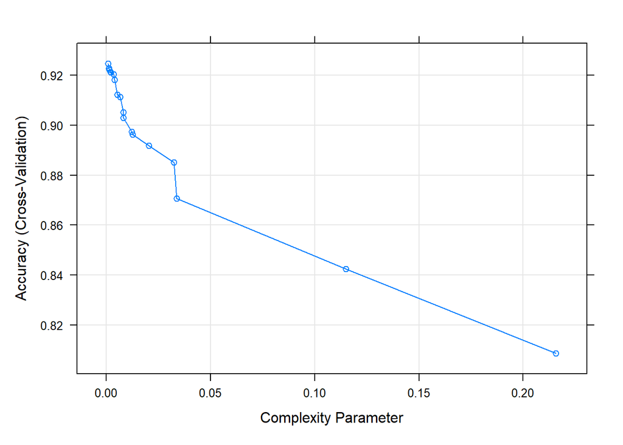

```r
# Fit the model on the training set
set.seed(1234)
caret.tree <- train(as.factor(loan_status) ~ person_income +
    person_emp_length + loan_amnt + loan_int_rate + person_home_ownership +
    loan_intent + loan_grade + loan_percent_income, data = fcr_train_tree,
    method = "rpart", trControl = trainControl("cv", number = 5,
        search = "grid", returnResamp = "final"), tuneLength = 20)
# Plot model accuracy vs different values of cp (complexity
# parameter)
plot(caret.tree)
```

```r
caret.tree
```

```
## CART
##
## 26059 samples
##     8 predictor
##     2 classes: '0', '1'
##
## No pre-processing
## Resampling: Cross-Validated (5 fold)
## Summary of sample sizes: 20847, 20847, 20848, 20847, 20847
## Resampling results across tuning parameters:
##
##   cp            Accuracy   Kappa
##   0.0008781173  0.9247479  0.7544905
##   0.0011415525  0.9228676  0.7478875
##   0.0012293642  0.9225606  0.7467760
##   0.0012586348  0.9225606  0.7467760
##   0.0014635289  0.9220234  0.7447789
##   0.0019318581  0.9213326  0.7420910
##   0.0021074816  0.9210640  0.7411880
##   0.0035124693  0.9204116  0.7394080
##   0.0039222573  0.9181475  0.7299874
##   0.0052687039  0.9121608  0.7072620
##   0.0064980681  0.9112782  0.7032548
##   0.0080786793  0.9051384  0.6749117
##   0.0081840534  0.9029127  0.6648955
##   0.0121180190  0.8973868  0.6497519
##   0.0124692659  0.8963123  0.6474650
##   0.0203723217  0.8918224  0.6348701
##   0.0324903407  0.8850681  0.6067465
##   0.0336318932  0.8706014  0.5279197
##   0.1150333685  0.8423573  0.4161644
##   0.2156656129  0.8085488  0.2372636
##
## Accuracy was used to select the optimal model using the largest value.
## The final value used for the model was cp = 0.0008781173.
```

```r
caret.tree$bestTune
```

```
##             cp
## 1 0.0008781173
```

Realizando la validación cruzada vemos que el CP óptimo para nuestro modelo de árbol de decisión se encuentra en 0.0008781173.

Visualizamos graficamente el árbol obtenido:

[figure not shown]

```r
# Plot the final tree model
par(xpd = NA)  # Avoid clipping the text in some device
plot(caret.tree$finalModel, uniform = TRUE)
text(caret.tree$finalModel, digits = 10)
```

```r
get_best_result = function(caret_fit) {
    best = which(rownames(caret_fit$results) == rownames(caret_fit$bestTune))
    best_result = caret_fit$results[best, ]
    rownames(best_result) = NULL
    best_result
}

get_best_result(caret.tree)
```

```
##             cp  Accuracy     Kappa  AccuracySD    KappaSD
## 1 0.0008781173 0.9247479 0.7544905 0.004037143 0.01365907
```

Se obtiene finalmente haciendo validación cruzada una precisión del 92/93%, con un modelo que ha sido comprobado como robusto y generalizable para funcionar previsiblemente en otro conjunto de datos diferente.

Evaluación del rendimiento predictivo del modelo Decision Tree presentado con las datos de train (metrica de evaluación utilizada de referencia: “Accuracy”, “Recall”, “Precision”, “F1” y “ROC”, y punto de corte utilizado: 0.5):

```r
fcr_train_tree$y_pred_probs2 <- predict(caret.tree, newdata = fcr_train_tree,
    type = "prob")
fcr_train_tree$y_pred_probs2 <- ifelse(fcr_train_tree$y_pred_probs2$`1` >
    0.5, fcr_train_tree$y_pred_probs2$`1`, 1 - fcr_train_tree$y_pred_probs2$`0`)

fcr_train_tree$y_pred2 <- ifelse(fcr_train_tree$y_pred_probs2 >
    0.5, 1, 0)

# fcr_train_tree$y_pred_probs2 fcr_train_tree$y_pred2
```

Se reproduce la matriz de confusión y las métricas de evaluación sobre el modelo final de Decision Tree obtenido:

```r
cm_train_tree <- confusionMatrix(as.factor(fcr_train_tree$y_pred2),
    as.factor(fcr_train_tree$loan_status), positive = "1")
cm_train_tree$table
```

```
##           Reference
## Prediction     0     1
##          0 20209  1746
##          1   156  3948
```

```r
# result
accuracy_modelo_tree_tune <- cm_train_tree$overall["Accuracy"] %>%
    round(4)
accuracy_modelo_tree_tune
```

```
## Accuracy
##    0.927
```

```r
# result
recall_modelo_tree_tune <- cm_train_tree$byClass["Recall"] %>%
    round(4)
recall_modelo_tree_tune
```

```
## Recall
## 0.6934
```

```r
# result
precision_modelo_tree_tune <- cm_train_tree$byClass["Precision"] %>%
    round(4)
precision_modelo_tree_tune
```

```
## Precision
##     0.962
```

```r
# result
F1Score_modelo_tree_tune <- (2 * (precision_modelo_tree_tune *
    recall_modelo_tree_tune)/(precision_modelo_tree_tune + recall_modelo_tree_tune)) %>%
    round(4)
F1Score_modelo_tree_tune
```

```
## Precision
##    0.8059
```

Se reproduce la curva ROC sobre el modelo final de árbol de decisión obtenido:

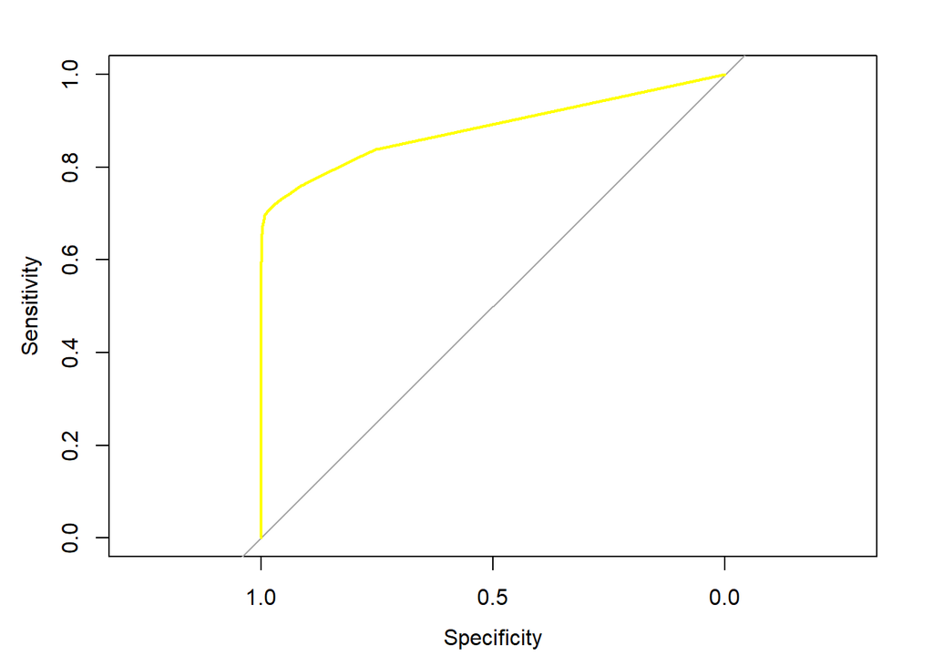

```r
roc_tree <- plot.roc(as.numeric(fcr_train_tree$loan_status),
    as.numeric(fcr_train_tree$y_pred_probs2), col = "yellow")
```

```r
auc(roc_tree)
```

```
## Area under the curve: 0.8829
```

Se obtiene alrededor de un 88.29% de área bajo la curva.

# 9. RANDOM FOREST

Primero se crean unos datos de train específicos para ser usados en el desarrollo del modelo de random forest, y así mantener los originales sin modificar.

```r
fcr_train_forest <- fcr_train
fcr_train_forest
```

```
## # A tibble: 26,059 × 12
##    person_age person_i…¹ perso…² perso…³ loan_…⁴ loan_…⁵ loan_…⁶ loan_…⁷ loan_…⁸
##         <dbl>      <dbl> <fct>     <dbl> <fct>   <fct>     <dbl>   <dbl>   <dbl>
##  1         28      44000 RENT          2 MEDICAL C         10000   13.5        1
##  2         21      35000 OWN           5 VENTURE B          8000    9.91       0
##  3         25      96000 MORTGA…       6 HOMEIM… C         21000   14.6        0
##  4         22      67000 OWN           5 EDUCAT… D          7500   16.3        0
##  5         24      52800 RENT          8 PERSON… A          9000    7.49       0
##  6         27      50004 RENT         12 DEBTCO… B          3200   11.5        0
##  7         23      55488 RENT          4 MEDICAL D          5000   15.2        1
##  8         28      70000 RENT          2 DEBTCO… B          6000   10.4        0
##  9         22      55000 MORTGA…       6 PERSON… C         13000   13.8        0
## 10         26      43200 RENT          5 EDUCAT… C          3200   14.4        0
## # … with 26,049 more rows, 3 more variables: loan_percent_income <dbl>,
## #   cb_person_default_on_file <fct>, cb_person_cred_hist_length <dbl>, and
## #   abbreviated variable names ¹person_income, ²person_home_ownership,
## #   ³person_emp_length, ⁴loan_intent, ⁵loan_grade, ⁶loan_amnt, ⁷loan_int_rate,
## #   ⁸loan_status
```

Se examina la convergencia del error en las muestras:

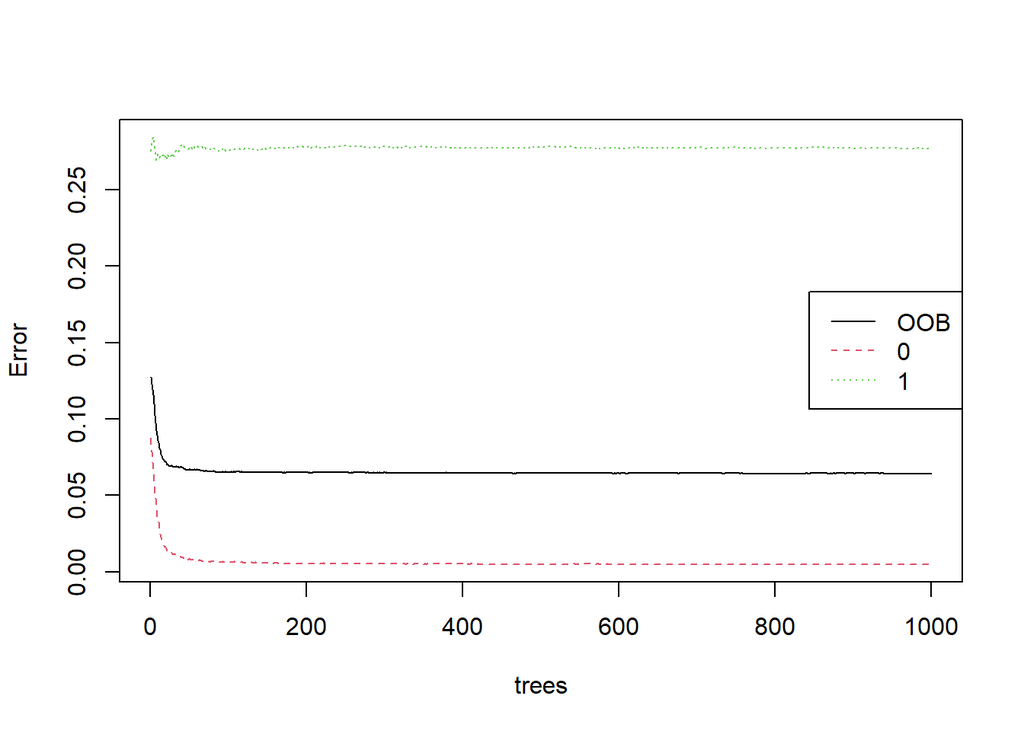

```r
plot(rf, main = "")
legend("right", colnames(rf$err.rate), lty = 1:5, col = 1:6)
```

Se analiza la relevancia de las variables en el modelo:

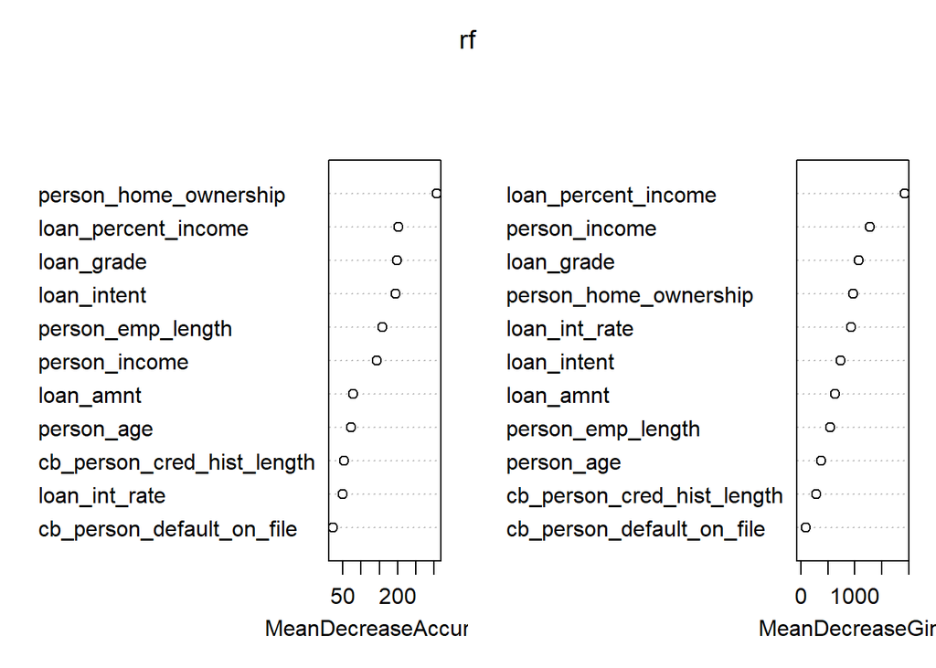

```r
varImpPlot(rf)
```

Como se puede observar, en el caso del modelo de Random Forest, las variables que mayor relavancia parecen tener en la definición de la capacidad predictora del mismo son “loan_percent_income”, “loan_grade”, “person_home_ownership”, “person_income” y “loan_intent”.

## 9.1. RANDOM FOREST - Cross Validation, Hiperparámetros y Evaluación del modelo

Se trata de aplicar Cross Validation sobre el modelo de random forest y realizar una selección de hiperparámetros (se busca tener un modelo robusto, generalizable y comparable con el resto para la posterior selección del mejor):

Vemos que el principal parámetro a configurar es el número de predictores al azar que toma el modelo.

```r
modelLookup("rf")
```

```
##   model parameter                         label forReg forClass probModel
## 1    rf      mtry #Randomly Selected Predictors   TRUE     TRUE      TRUE
```

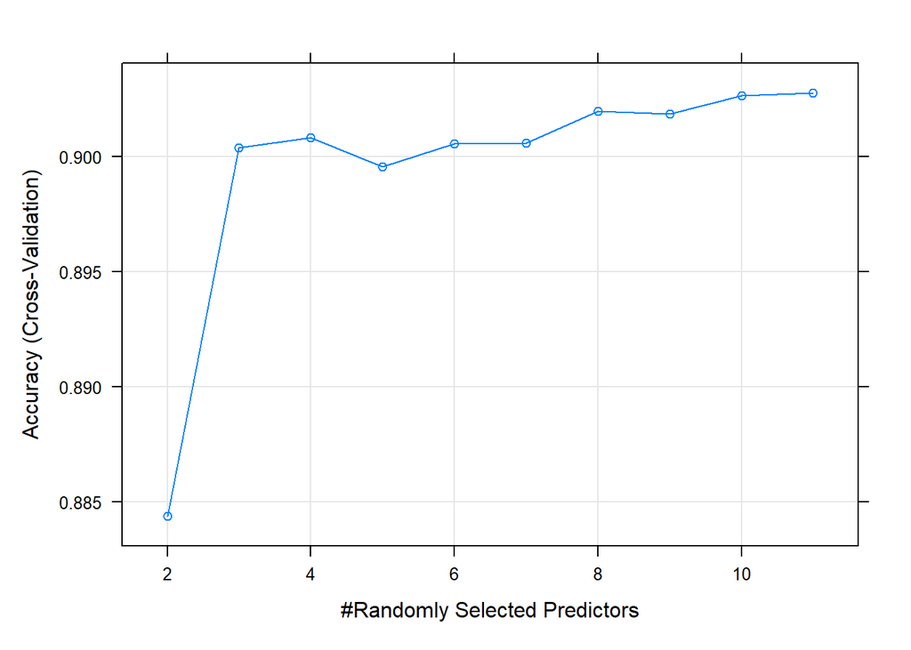

```r
# Fit the model on the training set
set.seed(12345)

caret.rf <- train(as.factor(loan_status) ~ loan_percent_income +
    person_income + loan_grade + person_home_ownership, data = fcr_train_forest,
    method = "rf", ntree = 20, importance = TRUE, metric = "Accuracy",
    trControl = trainControl("cv", number = 5, search = "grid",
        returnResamp = "final"), nodesize = 30, tuneLength = 10)

plot(caret.rf)
```

```r
caret.rf
```

```
## Random Forest
##
## 26059 samples
##     4 predictor
##     2 classes: '0', '1'
##
## No pre-processing
## Resampling: Cross-Validated (5 fold)
## Summary of sample sizes: 20847, 20848, 20847, 20847, 20847
## Resampling results across tuning parameters:
##
##   mtry  Accuracy   Kappa
##    2    0.8843781  0.6196875
##    3    0.9003799  0.6870654
##    4    0.9008020  0.6890992
##    5    0.8995356  0.6844077
##    6    0.9005334  0.6882959
##    7    0.9005717  0.6884403
##    8    0.9019532  0.6920956
##    9    0.9018382  0.6899826
##   10    0.9026440  0.6922755
##   11    0.9027592  0.6920294
##
## Accuracy was used to select the optimal model using the largest value.
## The final value used for the model was mtry = 11.
```

```r
caret.rf$bestTune
```

```
##    mtry
## 10   11
```

```r
get_best_result = function(caret_fit) {
    best = which(rownames(caret_fit$results) == rownames(caret_fit$bestTune))
    best_result = caret_fit$results[best, ]
    rownames(best_result) = NULL
    best_result
}

get_best_result(caret.rf)
```

```
##   mtry  Accuracy     Kappa  AccuracySD     KappaSD
## 1   11 0.9027592 0.6920294 0.002483855 0.006137814
```

```r
fcr_train_forest$y_pred_probs2 <- predict(caret.rf, newdata = fcr_train_forest,
    type = "prob")
fcr_train_forest$y_pred_probs2 <- ifelse(fcr_train_forest$y_pred_probs2$`1` >
    0.5, fcr_train_forest$y_pred_probs2$`1`, 1 - fcr_train_forest$y_pred_probs2$`0`)

fcr_train_forest$y_pred2 <- ifelse(fcr_train_forest$y_pred_probs2 >
    0.5, 1, 0)

# fcr_train_forest$y_pred_probs2 fcr_train_forest$y_pred2
# fcr_train_forest
```

```r
cm_train_forest <- confusionMatrix(as.factor(fcr_train_forest$y_pred2),
    as.factor(fcr_train_forest$loan_status), positive = "1")
cm_train_forest$table
```

```
##           Reference
## Prediction     0     1
##          0 19924  1669
##          1   441  4025
```

```r
# result
accuracy_modelo_forest_tune <- cm_train_forest$overall["Accuracy"] %>%
    round(4)
accuracy_modelo_forest_tune
```

```
## Accuracy
##    0.919
```

```r
# result
recall_modelo_forest_tune <- cm_train_forest$byClass["Recall"] %>%
    round(4)
recall_modelo_forest_tune
```

```
## Recall
## 0.7069
```

```r
# result
precision_modelo_forest_tune <- cm_train_forest$byClass["Precision"] %>%
    round(4)
precision_modelo_forest_tune
```

```
## Precision
##    0.9013
```

```r
# result
F1Score_modelo_forest_tune <- (2 * (precision_modelo_forest_tune *
    recall_modelo_forest_tune)/(precision_modelo_forest_tune +
    recall_modelo_forest_tune)) %>%
    round(4)
F1Score_modelo_forest_tune
```

```
## Precision
##    0.7924
```

Se reproduce la curva ROC sobre el modelo final de random forest obtenido:

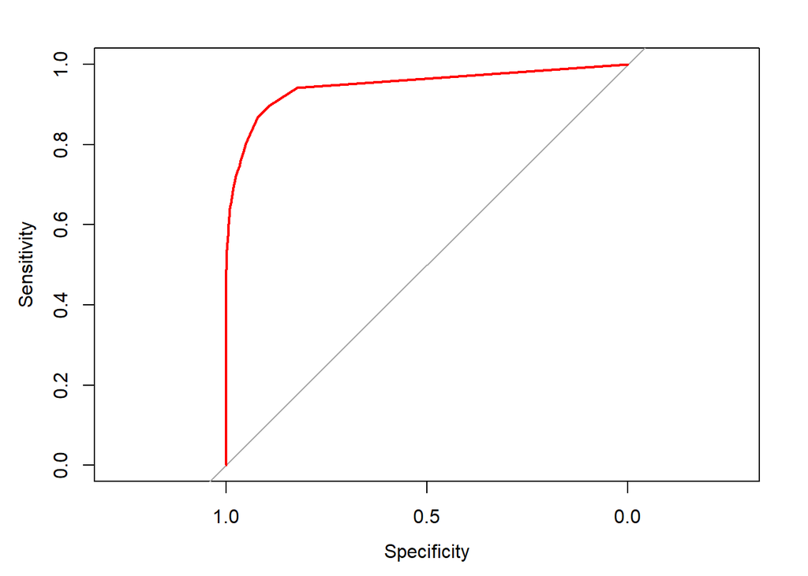

```r
roc_forest <- plot.roc(as.numeric(fcr_train_forest$loan_status),
    as.numeric(fcr_train_forest$y_pred_probs2), col = "red")
```

```r
auc(roc_forest)
```

```
## Area under the curve: 0.9473
```

Se obtiene alrededor de un 94.73% de área bajo la curva.

# 10. ADABoost - Boosted Classification Tree

Primero se crean unos datos de train específicos para ser usados en el desarrollo del modelo de ADABoost, y así mantener los originales sin modificar.

```r
fcr_train_ADABoost <- fcr_train
fcr_train_ADABoost
```

```
## # A tibble: 26,059 × 12
##    person_age person_i…¹ perso…² perso…³ loan_…⁴ loan_…⁵ loan_…⁶ loan_…⁷ loan_…⁸
##         <dbl>      <dbl> <fct>     <dbl> <fct>   <fct>     <dbl>   <dbl>   <dbl>
##  1         28      44000 RENT          2 MEDICAL C         10000   13.5        1
##  2         21      35000 OWN           5 VENTURE B          8000    9.91       0
##  3         25      96000 MORTGA…       6 HOMEIM… C         21000   14.6        0
##  4         22      67000 OWN           5 EDUCAT… D          7500   16.3        0
##  5         24      52800 RENT          8 PERSON… A          9000    7.49       0
##  6         27      50004 RENT         12 DEBTCO… B          3200   11.5        0
##  7         23      55488 RENT          4 MEDICAL D          5000   15.2        1
##  8         28      70000 RENT          2 DEBTCO… B          6000   10.4        0
##  9         22      55000 MORTGA…       6 PERSON… C         13000   13.8        0
## 10         26      43200 RENT          5 EDUCAT… C          3200   14.4        0
## # … with 26,049 more rows, 3 more variables: loan_percent_income <dbl>,
## #   cb_person_default_on_file <fct>, cb_person_cred_hist_length <dbl>, and
## #   abbreviated variable names ¹person_income, ²person_home_ownership,
## #   ³person_emp_length, ⁴loan_intent, ⁵loan_grade, ⁶loan_amnt, ⁷loan_int_rate,
## #   ⁸loan_status
```

Se crea el modelo de boosting con una configuración inicial básica de parámetros:

```r
ada.boost <- ada(as.factor(loan_status) ~ ., data = fcr_train_ADABoost,
    type = "real", control = rpart.control(maxdepth = 2, cp = 0,
        minsplit = 10, xval = 0), iter = 150, nu = 0.05)
ada.boost
```

```
## Call:
## ada(as.factor(loan_status) ~ ., data = fcr_train_ADABoost, type = "real",
##     control = rpart.control(maxdepth = 2, cp = 0, minsplit = 10,
##         xval = 0), iter = 150, nu = 0.05)
##
## Loss: exponential Method: real   Iteration: 150
##
## Final Confusion Matrix for Data:
##           Final Prediction
## True value     0     1
##          0 20147   218
##          1  1854  3840
##
## Train Error: 0.08
##
## Out-Of-Bag Error:  0.087  iteration= 150
##
## Additional Estimates of number of iterations:
##
## train.err1 train.kap1
##        150        150
```

Se analiza la evolución decreciente del error al aumentar el número de iteraciones en el modelo

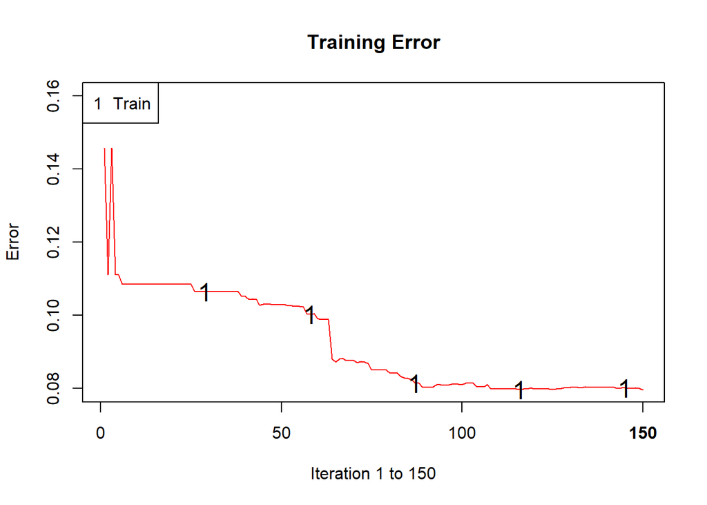

```r
plot(ada.boost)
```

Se pasa a evaluar la precisión del modelo en la muestra de train:

```r
set.seed(123)
pred_ada <- predict(ada.boost, newdata = fcr_train_ADABoost)
caret::confusionMatrix(pred_ada, as.factor(fcr_train_ADABoost$loan_status),
    positive = "1")
```

```
## Confusion Matrix and Statistics
##
##           Reference
## Prediction     0     1
##          0 20147  1854
##          1   218  3840
##
##                Accuracy : 0.9205
##                  95% CI : (0.9171, 0.9237)
##     No Information Rate : 0.7815
##     P-Value [Acc > NIR] : < 2.2e-16
##
##                   Kappa : 0.7403
##
##  Mcnemar's Test P-Value : < 2.2e-16
##
##             Sensitivity : 0.6744
##             Specificity : 0.9893
##          Pos Pred Value : 0.9463
##          Neg Pred Value : 0.9157
##              Prevalence : 0.2185
##          Detection Rate : 0.1474
##    Detection Prevalence : 0.1557
##       Balanced Accuracy : 0.8318
##
##        'Positive' Class : 1
##
```

Con la configuración de parámetros realizada en el modelo ada de booting se obtiene un valor de accuracy del 92% para el caso de algoritmos de clasificación.

Para optimizar los resultados del modelo creado y la generalización del modelo, se puede realizar un ajuste de hiperparámetros y validación cruzada:

```r
modelLookup("ada")
```

```
##   model parameter          label forReg forClass probModel
## 1   ada      iter         #Trees  FALSE     TRUE      TRUE
## 2   ada  maxdepth Max Tree Depth  FALSE     TRUE      TRUE
## 3   ada        nu  Learning Rate  FALSE     TRUE      TRUE
```

Se ven los parámetros de “iter”, “maxdepth” y “nu” que tiene el modelo ada de boosting para árboles de decisión en problemas de clasificación.

```r
set.seed(123)
caret.ada <- train(as.factor(loan_status) ~ ., method = "ada",
    data = fcr_train_ADABoost, trControl = trainControl(method = "cv",
        number = 5, search = "grid", returnResamp = "final"))
caret.ada
```

```
## Boosted Classification Trees
##
## 26059 samples
##    11 predictor
##     2 classes: '0', '1'
##
## No pre-processing
## Resampling: Cross-Validated (5 fold)
## Summary of sample sizes: 20848, 20847, 20847, 20847, 20847
## Resampling results across tuning parameters:
##
##   maxdepth  iter  Accuracy   Kappa
##   1          50   0.8378294  0.3706354
##   1         100   0.8556738  0.4675745
##   1         150   0.8621974  0.5059552
##   2          50   0.8708702  0.5361573
##   2         100   0.8843396  0.6036405
##   2         150   0.8900958  0.6314373
##   3          50   0.8948157  0.6459253
##   3         100   0.9014163  0.6776206
##   3         150   0.9036804  0.6875708
##
## Tuning parameter 'nu' was held constant at a value of 0.1
## Accuracy was used to select the optimal model using the largest value.
## The final values used for the model were iter = 150, maxdepth = 3 and nu = 0.1.
```

Se obtiene una configuración óptima de los hiperparámetros del modelo en “iter” = 150, “maxdepth” = 3 y “nu” = 0.1.

```r
caret.ada
```

```
## Boosted Classification Trees
##
## 26059 samples
##    11 predictor
##     2 classes: '0', '1'
##
## No pre-processing
## Resampling: Cross-Validated (5 fold)
## Summary of sample sizes: 20848, 20847, 20847, 20847, 20847
## Resampling results across tuning parameters:
##
##   maxdepth  iter  Accuracy   Kappa
##   1          50   0.8378294  0.3706354
##   1         100   0.8556738  0.4675745
##   1         150   0.8621974  0.5059552
##   2          50   0.8708702  0.5361573
##   2         100   0.8843396  0.6036405
##   2         150   0.8900958  0.6314373
##   3          50   0.8948157  0.6459253
##   3         100   0.9014163  0.6776206
##   3         150   0.9036804  0.6875708
##
## Tuning parameter 'nu' was held constant at a value of 0.1
## Accuracy was used to select the optimal model using the largest value.
## The final values used for the model were iter = 150, maxdepth = 3 and nu = 0.1.
```

```r
caret.ada$bestTune
```

```
##   iter maxdepth  nu
## 9  150        3 0.1
```

Con el modelo de base se obtiene un accuracy del 90% con los datos de train.

```r
get_best_result = function(caret_fit) {
    best = which(rownames(caret_fit$results) == rownames(caret_fit$bestTune))
    best_result = caret_fit$results[best, ]
    rownames(best_result) = NULL
    best_result
}

get_best_result(caret.ada)
```

```
##    nu maxdepth iter  Accuracy     Kappa  AccuracySD    KappaSD
## 1 0.1        3  150 0.9036804 0.6875708 0.004402523 0.01426331
```

Evaluación del rendimiento predictivo del modelo Ada Boost presentado con las datos de train (metrica de evaluación utilizada de referencia: “Accuracy”, “Recall”, “Precision”, “F1” y “ROC”, y punto de corte utilizado: 0.5):

```r
fcr_train_ADABoost$y_pred_probs2 <- predict(caret.ada, newdata = fcr_train_ADABoost,
    type = "prob")
fcr_train_ADABoost$y_pred_probs2 <- ifelse(fcr_train_ADABoost$y_pred_probs2$`1` >
    0.5, fcr_train_ADABoost$y_pred_probs2$`1`, 1 - fcr_train_ADABoost$y_pred_probs2$`0`)

fcr_train_ADABoost$y_pred2 <- ifelse(fcr_train_ADABoost$y_pred_probs2 >
    0.5, 1, 0)

# fcr_train_ADABoost$y_pred_probs2
# fcr_train_ADABoost$y_pred2 fcr_train_ADABoost
```

Se reproduce la matriz de confusión y las métricas de evaluación sobre el modelo final de ADABoost obtenido:

```r
cm_train_ada <- confusionMatrix(as.factor(fcr_train_ADABoost$y_pred2),
    as.factor(fcr_train_ADABoost$loan_status), positive = "1")
cm_train_ada$table
```

```
##           Reference
## Prediction     0     1
##          0 19893  2037
##          1   472  3657
```

```r
# result
accuracy_modelo_ada_tune <- cm_train_ada$overall["Accuracy"] %>%
    round(4)
accuracy_modelo_ada_tune
```

```
## Accuracy
##   0.9037
```

```r
# result
recall_modelo_ada_tune <- cm_train_ada$byClass["Recall"] %>%
    round(4)
recall_modelo_ada_tune
```

```
## Recall
## 0.6423
```

```r
# result
precision_modelo_ada_tune <- cm_train_ada$byClass["Precision"] %>%
    round(4)
precision_modelo_ada_tune
```

```
## Precision
##    0.8857
```

```r
# result
F1Score_modelo_ada_tune <- (2 * (precision_modelo_ada_tune *
    recall_modelo_ada_tune)/(precision_modelo_ada_tune + recall_modelo_ada_tune)) %>%
    round(4)
F1Score_modelo_ada_tune
```

```
## Precision
##    0.7446
```

Se reproduce la curva ROC sobre el modelo final de ADABoost obtenido:

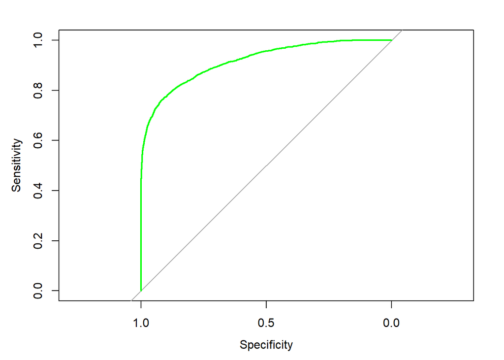

```r
roc_ada <- plot.roc(as.numeric(fcr_train_ADABoost$loan_status),
    as.numeric(fcr_train_ADABoost$y_pred_probs2), col = "green")
```

```r
auc(roc_ada)
```

```
## Area under the curve: 0.9169
```

Se obtiene alrededor de un 91.69% de área bajo la curva.

# 11. XGBoost - Extreme Gradient Boosting

Primero se crean unos datos de train específicos para ser usados en el desarrollo del modelo de XGBoost, y así mantener los originales sin modificar.

```r
fcr_train_XGBoost <- fcr_train
fcr_train_XGBoost
```

```
## # A tibble: 26,059 × 12
##    person_age person_i…¹ perso…² perso…³ loan_…⁴ loan_…⁵ loan_…⁶ loan_…⁷ loan_…⁸
##         <dbl>      <dbl> <fct>     <dbl> <fct>   <fct>     <dbl>   <dbl>   <dbl>
##  1         28      44000 RENT          2 MEDICAL C         10000   13.5        1
##  2         21      35000 OWN           5 VENTURE B          8000    9.91       0
##  3         25      96000 MORTGA…       6 HOMEIM… C         21000   14.6        0
##  4         22      67000 OWN           5 EDUCAT… D          7500   16.3        0
##  5         24      52800 RENT          8 PERSON… A          9000    7.49       0
##  6         27      50004 RENT         12 DEBTCO… B          3200   11.5        0
##  7         23      55488 RENT          4 MEDICAL D          5000   15.2        1
##  8         28      70000 RENT          2 DEBTCO… B          6000   10.4        0
##  9         22      55000 MORTGA…       6 PERSON… C         13000   13.8        0
## 10         26      43200 RENT          5 EDUCAT… C          3200   14.4        0
## # … with 26,049 more rows, 3 more variables: loan_percent_income <dbl>,
## #   cb_person_default_on_file <fct>, cb_person_cred_hist_length <dbl>, and
## #   abbreviated variable names ¹person_income, ²person_home_ownership,
## #   ³person_emp_length, ⁴loan_intent, ⁵loan_grade, ⁶loan_amnt, ⁷loan_int_rate,
## #   ⁸loan_status
```

Para optimizar los resultados del modelo creado, se puede realizar un ajuste de hiperparámetros con validación cruzada:

```r
modelLookup("xgbTree")
```

```
##     model        parameter                          label forReg forClass
## 1 xgbTree          nrounds          # Boosting Iterations   TRUE     TRUE
## 2 xgbTree        max_depth                 Max Tree Depth   TRUE     TRUE
## 3 xgbTree              eta                      Shrinkage   TRUE     TRUE
## 4 xgbTree            gamma         Minimum Loss Reduction   TRUE     TRUE
## 5 xgbTree colsample_bytree     Subsample Ratio of Columns   TRUE     TRUE
## 6 xgbTree min_child_weight Minimum Sum of Instance Weight   TRUE     TRUE
## 7 xgbTree        subsample           Subsample Percentage   TRUE     TRUE
##   probModel
## 1      TRUE
## 2      TRUE
## 3      TRUE
## 4      TRUE
## 5      TRUE
## 6      TRUE
## 7      TRUE
```

Se crea el modelo de boosting con una configuración inicial dada de parámetros:

```r
set.seed(2)
caret.xgb <- train(as.factor(loan_status) ~ ., method = "xgbTree",
    data = fcr_train_XGBoost, trControl = trainControl(method = "cv",
        number = 5, search = "grid", returnResamp = "final"))
```

[output not shown]

[output cut: 305 more lines]

[output not shown]

```r
caret.xgb
```

```
## eXtreme Gradient Boosting
##
## 26059 samples
##    11 predictor
##     2 classes: '0', '1'
##
## No pre-processing
## Resampling: Cross-Validated (5 fold)
## Summary of sample sizes: 20847, 20847, 20848, 20847, 20847
## Resampling results across tuning parameters:
##
##   eta  max_depth  colsample_bytree  subsample  nrounds  Accuracy   Kappa
##   0.3  1          0.6               0.50        50      0.8846845  0.6293761
##   0.3  1          0.6               0.50       100      0.8876393  0.6462293
##   0.3  1          0.6               0.50       150      0.8884836  0.6510768
##   0.3  1          0.6               0.75        50      0.8834950  0.6266359
##   0.3  1          0.6               0.75       100      0.8876394  0.6473287
##   0.3  1          0.6               0.75       150      0.8880999  0.6493912
##   0.3  1          0.6               1.00        50      0.8841473  0.6284229
##   0.3  1          0.6               1.00       100      0.8874091  0.6451641
##   0.3  1          0.6               1.00       150      0.8880231  0.6492723
##   0.3  1          0.8               0.50        50      0.8847996  0.6308522
##   0.3  1          0.8               0.50       100      0.8875626  0.6466938
##   0.3  1          0.8               0.50       150      0.8891360  0.6523035
##   0.3  1          0.8               0.75        50      0.8829193  0.6250569
##   0.3  1          0.8               0.75       100      0.8876777  0.6467031
##   0.3  1          0.8               0.75       150      0.8890975  0.6525131
##   0.3  1          0.8               1.00        50      0.8827275  0.6247079
##   0.3  1          0.8               1.00       100      0.8873708  0.6458530
##   0.3  1          0.8               1.00       150      0.8882534  0.6496125
##   0.3  2          0.6               0.50        50      0.9103187  0.7125871
##   0.3  2          0.6               0.50       100      0.9198356  0.7437571
##   0.3  2          0.6               0.50       150      0.9227906  0.7536219
##   0.3  2          0.6               0.75        50      0.9113931  0.7156087
##   0.3  2          0.6               0.75       100      0.9216009  0.7488730
##   0.3  2          0.6               0.75       150      0.9246708  0.7589696
##   0.3  2          0.6               1.00        50      0.9098968  0.7116771
##   0.3  2          0.6               1.00       100      0.9206800  0.7461793
##   0.3  2          0.6               1.00       150      0.9249780  0.7599866
##   0.3  2          0.8               0.50        50      0.9109328  0.7142251
```

[output cut: 73 more lines]

```
##   0.4  3          0.8               0.50       150      0.9299282  0.7779567
##   0.4  3          0.8               0.75        50      0.9263595  0.7640630
##   0.4  3          0.8               0.75       100      0.9308109  0.7789249
##   0.4  3          0.8               0.75       150      0.9317703  0.7830458
##   0.4  3          0.8               1.00        50      0.9270885  0.7663427
##   0.4  3          0.8               1.00       100      0.9319620  0.7823425
##   0.4  3          0.8               1.00       150      0.9330749  0.7865927
##
## Tuning parameter 'gamma' was held constant at a value of 0
## Tuning
##  parameter 'min_child_weight' was held constant at a value of 1
## Accuracy was used to select the optimal model using the largest value.
## The final values used for the model were nrounds = 150, max_depth = 3, eta
##  = 0.4, gamma = 0, colsample_bytree = 0.8, min_child_weight = 1 and subsample
##  = 1.
```

Se obtiene una configuración óptima de los hiperparámetros del modelo en:

```r
get_best_result = function(caret_fit) {
    best = which(rownames(caret_fit$results) == rownames(caret_fit$bestTune))
    best_result = caret_fit$results[best, ]
    rownames(best_result) = NULL
    best_result
}

get_best_result(caret.xgb)
```

```
##   eta max_depth gamma colsample_bytree min_child_weight subsample nrounds
## 1 0.4         3     0              0.8                1         1     150
##    Accuracy     Kappa AccuracySD     KappaSD
## 1 0.9330749 0.7865927 0.00189919 0.006102938
```

Se analiza la relevancia de cada variable en el modelo:

```r
varImp(caret.xgb)
```

```
## xgbTree variable importance
##
##   only 20 most important variables shown (out of 22)
##
##                             Overall
## loan_percent_income        100.0000
## person_income               78.7401
## loan_int_rate               59.3389
## person_home_ownershipRENT   45.6475
## loan_gradeD                 31.4561
## person_home_ownershipOWN    14.4366
## person_emp_length           13.3073
## loan_intentHOMEIMPROVEMENT  11.3466
## loan_intentMEDICAL           6.9108
## loan_amnt                    6.4238
## loan_intentEDUCATION         6.3647
## loan_gradeE                  5.4250
## loan_intentVENTURE           5.1817
## person_age                   4.6696
## loan_gradeC                  2.5971
## loan_gradeG                  2.0848
## loan_intentPERSONAL          1.8264
## loan_gradeF                  1.5411
## cb_person_cred_hist_length   0.7322
## cb_person_default_on_fileY   0.5910
```

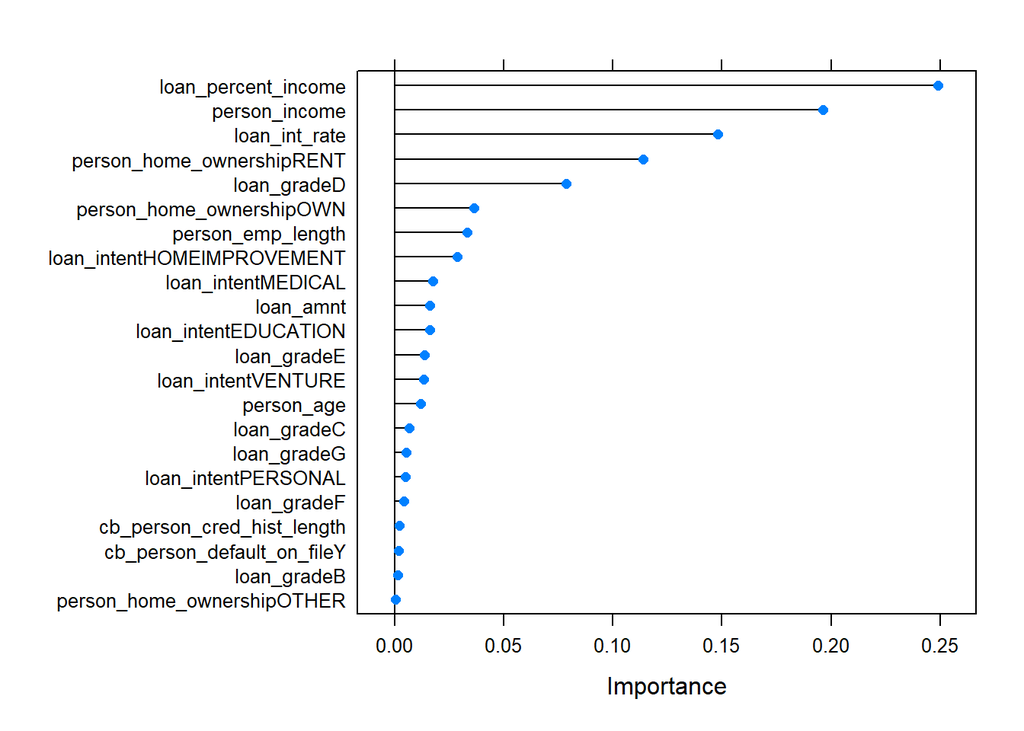

```r
RocImp_xgb <- varImp(caret.xgb, scale = FALSE)

plot(RocImp_xgb)
```

Como se puede observar, para el modelo de XGBoost las variables que mayor relevancia tienen a la hora de crear el algoritmo para la predicción del riesgo de impago son “loan_percent_income”, “person_income”, “loan_int_rate”, “person_home_ownership” en el caso de “Rent” o alquiler, y “loan_grade” en caso de clientes y operaciones con Scoring “D”.

Evaluación del rendimiento predictivo del modelo XG Boost presentado con las datos de train (metrica de evaluación utilizada de referencia: “Accuracy”, “Recall”, “Precision”, “F1” y “ROC”, y punto de corte utilizado: 0.5):

```r
fcr_train_XGBoost$y_pred_probs2 <- predict(caret.xgb, newdata = fcr_train_XGBoost,
    type = "prob")
fcr_train_XGBoost$y_pred_probs2 <- ifelse(fcr_train_XGBoost$y_pred_probs2$`1` >
    0.5, fcr_train_XGBoost$y_pred_probs2$`1`, 1 - fcr_train_XGBoost$y_pred_probs2$`0`)

fcr_train_XGBoost$y_pred2 <- ifelse(fcr_train_XGBoost$y_pred_probs2 >
    0.5, 1, 0)

# fcr_train_XGBoost$y_pred_probs2 fcr_train_XGBoost$y_pred2
# fcr_train_XGBoost
```

Se reproduce la matriz de confusión y las métricas de evaluación sobre el modelo final de XG Boost obtenido:

```r
cm_train_xgb <- confusionMatrix(as.factor(fcr_train_XGBoost$y_pred2),
    as.factor(fcr_train_XGBoost$loan_status), positive = "1")
cm_train_xgb$table
```

```
##           Reference
## Prediction     0     1
##          0 20252  1430
##          1   113  4264
```

```r
# result
accuracy_modelo_xgb_tune <- cm_train_xgb$overall["Accuracy"] %>%
    round(4)
accuracy_modelo_xgb_tune
```

```
## Accuracy
##   0.9408
```

```r
# result
recall_modelo_xgb_tune <- cm_train_xgb$byClass["Recall"] %>%
    round(4)
recall_modelo_xgb_tune
```

```
## Recall
## 0.7489
```

```r
# result
precision_modelo_xgb_tune <- cm_train_xgb$byClass["Precision"] %>%
    round(4)
precision_modelo_xgb_tune
```

```
## Precision
##    0.9742
```

```r
# result
F1Score_modelo_xgb_tune <- (2 * (precision_modelo_xgb_tune *
    recall_modelo_xgb_tune)/(precision_modelo_xgb_tune + recall_modelo_xgb_tune)) %>%
    round(4)
F1Score_modelo_xgb_tune
```

```
## Precision
##    0.8468
```

Se reproduce la curva ROC sobre el modelo final de XGBoost obtenido:

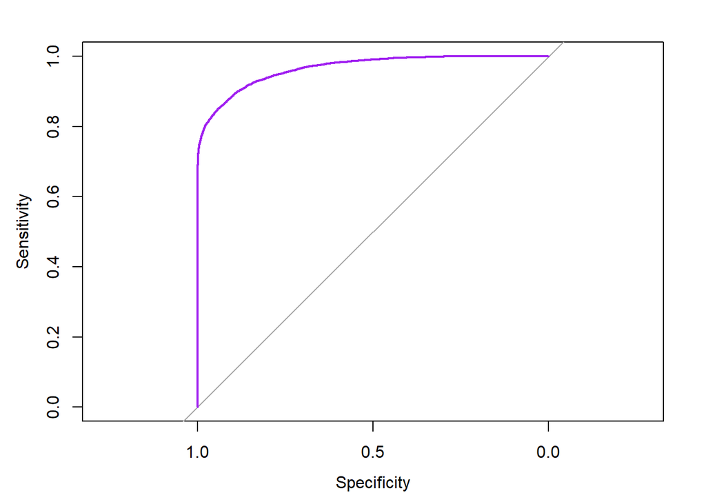

```r
roc_xgb <- plot.roc(as.numeric(fcr_train_XGBoost$loan_status),
    as.numeric(fcr_train_XGBoost$y_pred_probs2), col = "purple")
```

```r
auc(roc_xgb)
```

```
## Area under the curve: 0.9654
```

Se obtiene alrededor de un 96.54% de área bajo la curva.

# *COMPARACIÓN DE LAS TÉCNICAS Y MODELOS DE MACHINE LEARNING*

# 12. Comparación entre los diferentes modelos

Los modelo que han sido evaluados en este trabajo para los datos analizados han sido:

- **Modelo de regresión logística (GLM)**
- **Modelo de árbol de decisión (Decision Tree)**
- **Modelo de bosque (Random Forest)**
- **Modelo de métodos de ensamble (ADABoost y XGBoost)**

```r
accuracy <- c(accuracy_modelo_glm2_tune, accuracy_modelo_tree_tune,
    accuracy_modelo_forest_tune, accuracy_modelo_ada_tune, accuracy_modelo_xgb_tune)

recall <- c(recall_modelo_glm2_tune, recall_modelo_tree_tune,
    recall_modelo_forest_tune, recall_modelo_ada_tune, recall_modelo_xgb_tune)

precision <- c(precision_modelo_glm2_tune, precision_modelo_tree_tune,
    precision_modelo_forest_tune, precision_modelo_ada_tune,
    precision_modelo_xgb_tune)

F1Score <- c(F1Score_modelo_glm2_tune, F1Score_modelo_tree_tune,
    F1Score_modelo_forest_tune, F1Score_modelo_ada_tune, F1Score_modelo_xgb_tune)

ROC <- c(auc(roc_glm), auc(roc_tree), auc(roc_forest), auc(roc_ada),
    auc(roc_xgb))

modelo <- c("GLM", "Decision Tree", "Random Forest", "ADABoost",
    "XGBoost")

datos <- data.frame(modelo = modelo, accuracy = accuracy, recall = recall,
    precision = precision, F1Score = F1Score, ROC = ROC)

head(datos)
```

```
##          modelo accuracy recall precision F1Score       ROC
## 1           GLM   0.8671 0.5604    0.7689  0.6483 0.8703091
## 2 Decision Tree   0.9270 0.6934    0.9620  0.8059 0.8829187
## 3 Random Forest   0.9190 0.7069    0.9013  0.7924 0.9473037
## 4      ADABoost   0.9037 0.6423    0.8857  0.7446 0.9169275
## 5       XGBoost   0.9408 0.7489    0.9742  0.8468 0.9653826
```

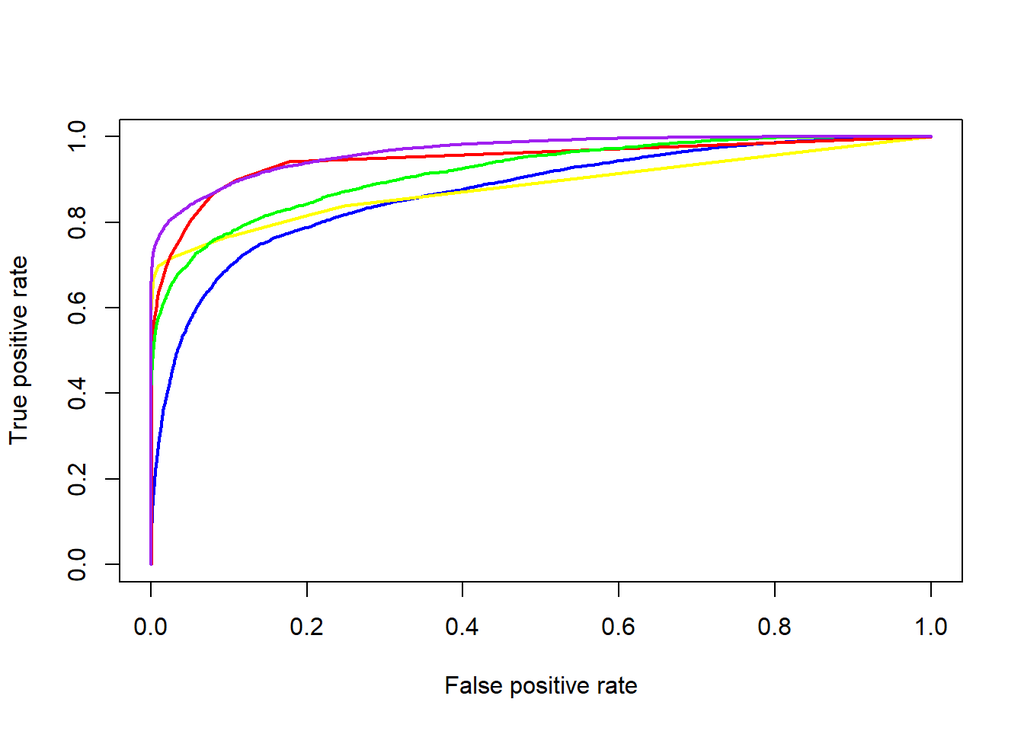

```r
# GLM
pred1 <- predict(modelo_glm2, fcr_train_glm, type = "response")
pred.glm <- prediction(pred1, fcr_train_glm$loan_status)
perf.glm <- performance(pred.glm, "tpr", "fpr")
plot(perf.glm, col = "blue", lwd = 2)

# DECISION TREE
pred3 <- predict(caret.tree, newdata = fcr_train_tree, type = "prob")
pred33 <- ifelse(pred3$`1` > 0.5, pred3$`1`, 1 - pred3$`0`)
pred.tree <- prediction(pred33, fcr_train_tree$loan_status)
perf.tree <- performance(pred.tree, "tpr", "fpr")
plot(perf.tree, add = TRUE, col = "yellow", lwd = 2)

# RANDOM FOREST
pred4 <- predict(caret.rf, newdata = fcr_train_forest, type = "prob")
pred44 <- ifelse(pred4$`1` > 0.5, pred4$`1`, 1 - pred4$`0`)
pred.rf <- prediction(pred44, fcr_train_forest$loan_status)
perf.rf <- performance(pred.rf, "tpr", "fpr")
plot(perf.rf, add = TRUE, col = "red", lwd = 2)

# ADA BOOST
pred5 <- predict(caret.ada, newdata = fcr_train_ADABoost, type = "prob")
pred55 <- ifelse(pred5$`1` > 0.5, pred5$`1`, 1 - pred5$`0`)
pred.ada <- prediction(pred55, fcr_train_ADABoost$loan_status)
perf.ada <- performance(pred.ada, "tpr", "fpr")
plot(perf.ada, add = TRUE, col = "green", lwd = 2)

# XG BOOST
pred6 <- predict(caret.xgb, newdata = fcr_train_XGBoost, type = "prob")
pred66 <- ifelse(pred6$`1` > 0.5, pred6$`1`, 1 - pred6$`0`)
pred.xgb <- prediction(pred66, fcr_train_XGBoost$loan_status)
perf.xgb <- performance(pred.xgb, "tpr", "fpr")
plot(perf.xgb, add = TRUE, col = "purple", lwd = 2)
```

Con los datos obtenidos, el algoritmo que mejores resultados ha arrojado es el de XGBoost, y será el que utilicemos en la posterior validación de los resultado.

# *VALIDACIÓN DE LOS RESULTADOS*

# 13. Comprobación de los resultados con los datos de test

## 13.1. Cambios, modificaciones y transformaciones sobre el dataset de test

Se realizan los cambios y modificaciones necesarias sobre el conjunto de datos de test, aplicados previamente sobre nuestro dataset de train:

- Ya se han realizado anteriormente la imputación de NAs del data set de test al valor de la mediana de la variable de referencia.
- Se ha optado finalmente en el trabajo por no tranformar ninguna variable a logaritmos, por lo que en el data set de test no habría que realizar nada al respecto.

## 13.2. Comprobación del mejor modelo con datos de test

**Comprobación del modelo de XG Boost con los datos de test:**

Se procede ahora a validar la capacidad predictora del modelo desarrollado de XG Boost con el conjunto de datos de test.

```r
fcr_test$y_pred_probs2 <- predict(caret.xgb, newdata = fcr_test,
    type = "prob")
fcr_test$y_pred_probs2 <- ifelse(fcr_test$y_pred_probs2$`1` >
    0.5, fcr_test$y_pred_probs2$`1`, 1 - fcr_test$y_pred_probs2$`0`)

fcr_test$y_pred2 <- ifelse(fcr_test$y_pred_probs2 > 0.5, 1, 0)

# fcr_test$y_pred_probs2 fcr_test$y_pred2 fcr_test
```

Se reproduce la matriz de confusión y las métricas de evaluación sobre el modelo final de XG Boost obtenido:

```r
cm_test_xgb <- confusionMatrix(as.factor(fcr_test$y_pred2), as.factor(fcr_test$loan_status),
    positive = "1")
cm_test_xgb$table
```

```
##           Reference
## Prediction    0    1
##          0 5045  380
##          1   57 1033
```

```r
# result
accuracy_modelo_xgb_tune_test <- cm_test_xgb$overall["Accuracy"] %>%
    round(4)
accuracy_modelo_xgb_tune_test
```

```
## Accuracy
##   0.9329
```

```r
# result
recall_modelo_xgb_tune_test <- cm_test_xgb$byClass["Recall"] %>%
    round(4)
recall_modelo_xgb_tune_test
```

```
## Recall
## 0.7311
```

```r
# result
precision_modelo_xgb_tune_test <- cm_test_xgb$byClass["Precision"] %>%
    round(4)
precision_modelo_xgb_tune_test
```

```
## Precision
##    0.9477
```

```r
# result
F1Score_modelo_xgb_tune_test <- (2 * (precision_modelo_xgb_tune_test *
    recall_modelo_xgb_tune_test)/(precision_modelo_xgb_tune_test +
    recall_modelo_xgb_tune_test)) %>%
    round(4)
F1Score_modelo_xgb_tune_test
```

```
## Precision
##    0.8254
```

Se comprueba el área bajo la curva para el modelo de XG Boost en el conjunto de datos de test:

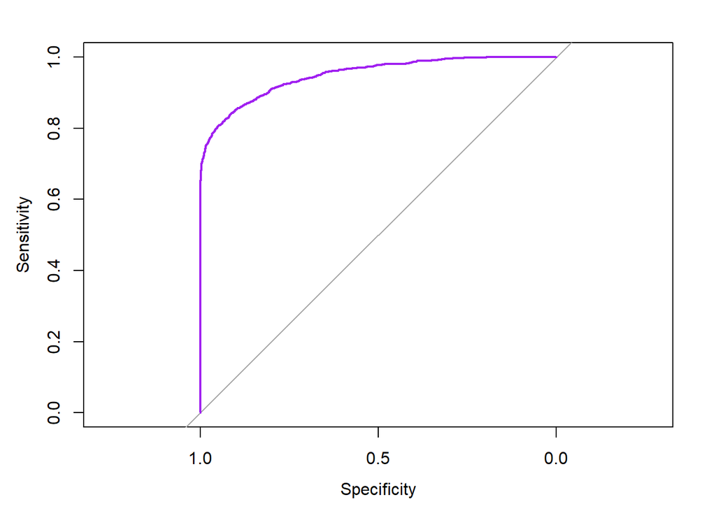

```r
roc_xgb_test <- plot.roc(as.numeric(fcr_test$loan_status), as.numeric(fcr_test$y_pred_probs2),
    col = "purple")
```

```r
auc(roc_xgb_test)
```

```
## Area under the curve: 0.9492
```

Se obtiene alrededor de un 94.92% de área bajo la curva.

## 13.2. Comparativa del mejor modelo con datos de train vs datos de test

**Comparativa del modelo de XG Boost en train y test:**

```r
accuracy2 <- c(accuracy_modelo_xgb_tune, accuracy_modelo_xgb_tune_test)

recall2 <- c(recall_modelo_xgb_tune, recall_modelo_xgb_tune_test)

precision2 <- c(precision_modelo_xgb_tune, precision_modelo_xgb_tune_test)

F1Score2 <- c(F1Score_modelo_xgb_tune, F1Score_modelo_xgb_tune_test)

ROC2 <- c(auc(roc_xgb), auc(roc_xgb_test))

datosreferencia <- c("train", "test")

modelo2 <- c("XGBoost", "XGBoost")

datos2 <- data.frame(modelo = modelo2, datos = datosreferencia,
    accuracy = accuracy2, recall = recall2, precision = precision2,
    F1Score = F1Score2, ROC = ROC2)

head(datos2)
```

```
##    modelo datos accuracy recall precision F1Score       ROC
## 1 XGBoost train   0.9408 0.7489    0.9742  0.8468 0.9653826
## 2 XGBoost  test   0.9329 0.7311    0.9477  0.8254 0.9491626
```

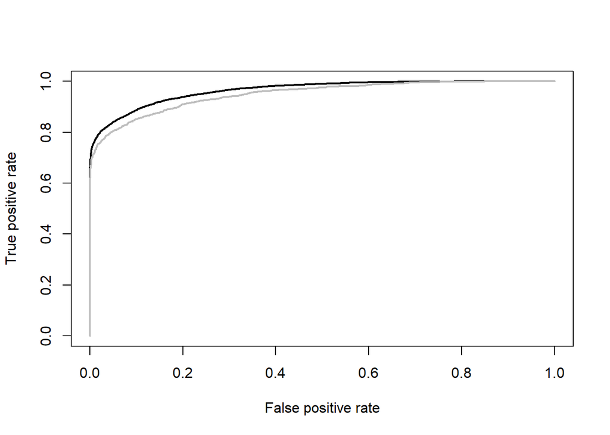

```r
# XG BOOST TRAIN
pred6 <- predict(caret.xgb, newdata = fcr_train_XGBoost, type = "prob")
pred66 <- ifelse(pred6$`1` > 0.5, pred6$`1`, 1 - pred6$`0`)
pred.xgb <- prediction(pred66, fcr_train_XGBoost$loan_status)
perf.xgb <- performance(pred.xgb, "tpr", "fpr")
plot(perf.xgb, col = "black", lwd = 2)

# XG BOOST TEST
pred7 <- predict(caret.xgb, newdata = fcr_test, type = "prob")
pred77 <- ifelse(pred7$`1` > 0.5, pred7$`1`, 1 - pred7$`0`)
pred.xgb2 <- prediction(pred77, fcr_test$loan_status)
perf.xgb2 <- performance(pred.xgb2, "tpr", "fpr")
plot(perf.xgb2, add = TRUE, col = "grey", lwd = 2)
```

Realizando la comprobación del modelo con los datos de test al final del análisis, se llega a la conclusión de que es un modelo generalizable, robusto y con resultados relativamente similares tanto en train como en test, siendo esto un resultado final del trabajo positivo.